# Small Business Demand Planning and Inventory Management

## OM 596 - Capstone Project

## By: Jeff Ward

## Commitee Members: Dr. Freeman, Dr. Keskin, Dr. Lodree

# Abstract

*This project introduces demand forecasting for a small business and provides a statistical analysis of the accuracy of the forecasts. Four forecasting methods are introduced to forecast the future demand for the business. The forecasts are then analyzed, and the winning forecast is produced as the forecast for the next year. This forecast can be used in guiding the small business in its reordering processes and help alleviate excess inventory.*

# Contents

- Project Description
  - 1.1 Introduction
  - 1.2 Problem Statement
  - 1.3 Scope of Work
- Data and Notebook Preparation
  - 2.1 Libraries
    - 2.2 Import and Data Preparation
- Sales Account Selection
- Sales - Spices Analysis
  - 4.1 ABC Analysis for Sales - Spices
    - 4.1.1 ABC Analysis Takeaway
    - 4.1.2 Account Sales Aggragation
  - 4.2. Forecasting and Analysis
    - 4.2.1 Basic Statistics
    - 4.2.2 Moving Average Model
      - 4.2.2.1 Moving Average Analysis
      - 4.2.2.2 Moving Average Takeaway
    - 4.2.3 Simple Exponential Smoothing Model
      - 4.2.3.1 Simple Exponential Smooting Analysis
      - 4.2.3.2 Simple Exponential Smooting Takeaway
    - 4.2.4 Holt-Winters Seasonal Smoothing Model
      - 4.4.4.1 Holt-Winters Seasonal Smoothing Analysis
      - 4.4.4.2 Holt-Winters Seasonal Smoothing Analysis Takeaway
    - 4.2.5 Seasonal ARIMA Model
      - 4.2.5.1 Seasonal ARIMA Analysis
      - 4.2.5.2 Seasonal ARIMA Analysis Takeaway
    - 4.2.6 Combined Forecast Analyasis
      - 4.2.6.1 Combined Forecast Analyasis Takeaway
- Multi Item Analysis
  - 5.1 Multi Item Forecast
- Conclusion
  - 6.1 Conclusion
  - 6.2 Recommendations
  - 6.3 Acknowledgements
  - 6.4 Useful Links and Resources
  - 6.5 Tools/ Techniques Checklist

# Project Description

## Introduction

In 1976 my Grandfather and my Dad started a business called Southeastern Butcher Supplies since then they have served customers in the food processing industry across the Southeast United States. The focus of their business is on the sales and service of meat processing equipment. However, in addition to their equipment they sell the supplies needed to process meat. These supplies include everything from wear and tear parts like blades to the packaging materials. Southeastern Butcher Supplies has three unique segments of their customer base: custom slaughterhouses, restaurants, and meat processing plants. Each of these segments have their own unique supplies they need and equipment.  
In Alabama it is of no surprise that people like to hunt deer and other wild game. This leads to several custom slaughterhouses across the state, the market for custom slaughterhouses is however extremely seasonal. So, from mid-October to early-February there are several of these operations that pop up at the beginning of the season and close at the end. This leads to extremely seasonal demand of the supplies and service that the custom slaughterhouses rely on.  
Most restaurants across the state rely on the meat to be processed at an external site and brought in on trucks. However, some of the more upscale restaurants preform some form of processing on site. This can include making their own sausage or hamburgers at the restaurant. This provides a consistent stream of demand for the supplies and service, but at a significantly smaller level.  
The final customer segment that the business serves is meat processing plants. Many of the meat products that restaurants use come from local meat processing plants. In more recent more processing plants have started to open due to the demand of “Organic” meat. These processing plants require a significant amount of supplies and service year-round. These processing plants also generate the some of the largest sales each year due to the sales of new equipment.  
While the company has been in business for over 40 years, there has been little advancement into the forecasting and demand planning that many large businesses currently have the privilege of using. But with all sales going through QuickBooks for the last two decades the company with the right tools has everything it needs to forecast the demand of its supplies.

## Problem Statement

Currently Southeaster Butcher Supplies has no method to produce accurate forecast for the seasonal demand of the products they sell. Their ordering procedure is dependent on intuition, this leads to excess inventory of some supplies and/ or stockouts. To help reduce the impact of seasonal demand on the demand of the year-round customers, a more accurate demand forecast needs to be made so that the business can serve its customers on a higher level. This project will provide the company with unique insights into their supplies sales and forecasts for desired sales accounts.

## Scope of Work

My solution to this problem is to create this notebook that uses the historical data to predict demand. The forecasts used to determine these inventory levels will include Time Series and Projection methods such as: Moving average, Simple Exponential Smoothing, Holt Winters Seasonal Smoothing, and Seasonal ARIMA. These forecasting models have been selected due to their existence in the OM 500 course content. These forecasts will use the data from 2010 – 2019 with the data from the last 12 months of the data to be used as a comparison to see how accurate the forecast was.  
The accuracy of each model will be measured by using three measures: Mean Absolute Deviation, Mean Squared Error, and their R^2 value. For the moving average, simple exponential smoothing, and Holt Winters Seasonal Smoothing there are multiple variations of the model so the model that has the most accurate forecast using the three measures will be passed as the winner for that model. After every model has ran the winning variation of the model will be passed to the Combined Forecast Analyasis for comparison. The winning model will then produce a demand forecast for the item.  
The tools and techniques used for this project can be seen in the Tools/ Techniques Checklist.

(see Tools/ Techniques Checklist)

# Data and Notebook Preparation

## Libraries

The libraries used for this project are imported below and are labeled as to the function they serve. There are basic libraries that you find in any python project such as NumPy and pandas that help with data manipulation. I have chosen Matplotlib for the plotting library for its versatility and its options to set styling. Additionally, more advanced libraries like statsmodels and scipy, have been imported to help develop the statistical models.

```python
#data manipulation
import numpy as np
import pandas as pd
import os
import math
import itertools
import warnings
warnings.filterwarnings("ignore")
from datetime import datetime
import dateutil.parser
import ipywidgets as widgets

#data visuliation
from IPython.display import display, HTML
import seaborn as sns
import matplotlib
from matplotlib import pyplot
from matplotlib.pyplot import figure
from matplotlib.ticker import PercentFormatter
import matplotlib.dates as mdates
pyplot.style.use('fivethirtyeight')
from pylab import rcParams
rcParams['figure.figsize'] = 18, 10

#statistical models
import statsmodels
from statsmodels.tsa.holtwinters import SimpleExpSmoothing
from statsmodels.tsa.holtwinters import Holt
from statsmodels.tsa.seasonal import seasonal_decompose
from statsmodels.api import OLS
from statsmodels.tsa.holtwinters import ExponentialSmoothing
from scipy import stats
import statsmodels.api as sm
import sklearn.metrics as sk
```

## Import and Data Preparation

The data comes from the company’s QuickBooks reporting module, within the module you can make custom reports of which I have done. The report looks at the line items of all sales over the last 10 years and exports them to a csv file. The reports are run in batches as there is a limit on the number of rows that it can export (about 3-4 years of data). Once the files are exported to csv the notebook looks in the folder in which it is contained to read the data and import it. There are some additional steps taken on the data import like adding a ‘Year’ and ‘YearMonth’ column. These columns correspond to the year or year and month that the line Item was sold according to the Ship-Date, this allows the line items to be aggregated easier. The data types of some of the columns have also been changed to date time and integers for various calculations.  
A few important things to notice about the data is the ‘Account’ column and the ‘Ship-Date.’ The Account column designates which sales account the line item belongs to. The Ship-Date corresponds to the date the item was sold, as the date billed can occur after the sale.

```python
#Create a list of all of the files in the current directory
os.listdir()

#Create a list of all data files change 'jan' if a new file nomenclature is used
all_files = [file for file in os.listdir() if file.startswith('jan')]

#Creates an empty dataframe
all_data  = pd.DataFrame()

#for loop to concatanate all data into the all_data dataframe
for file in all_files:
    all_data = pd.concat([all_data, pd.read_csv(file)])

#drops all records where the invoice number is na
all_data = all_data.dropna(subset = ['Num'])

all_data = all_data.reset_index(drop = True)

#set ship date to date time
all_data['Ship Date'] = pd.to_datetime(all_data['Ship Date'])

#set date to date time
all_data['Date'] = pd.to_datetime(all_data['Date'])

#drops where ship date is na this will provide with more accureate demand numbers
all_data = all_data.dropna(subset = ['Ship Date'])

#appends the year of the ship date
all_data.loc[:, 'Year'] = all_data['Ship Date'].dt.year.astype(str)

#appends the year of the ship date
all_data.loc[:, 'Yeara'] = all_data['Ship Date'].dt.strftime('%Y')
all_data.Yeara = pd.to_numeric(all_data.Yeara)
all_data = all_data[all_data.Yeara < 2020]

#appends the month of the ship date
#all_data.loc[:, 'Month'] = all_data['Ship Date'].dt.month.astype(int)

all_data.loc[:, 'YearMonth'] = all_data['Ship Date'].dt.strftime('%Y-%m')

#changes data to more appropreate data types
all_data.loc[:, 'Qty'] = all_data['Qty'].astype(int)
all_data.loc[:, 'Trans #'] = all_data['Trans #'].astype(int)
all_data.loc[:, 'Num'] = all_data['Num'].astype(int)
all_data.loc[:, 'Item'] = all_data['Item'].astype(str)

#eleminates negative quantities from the Qty column
#not going to forecast any negative numbers as they are tools utilized to credit a customer
#and the product is not resellable
num = all_data._get_numeric_data()
num[num < 0] = 0

all_data.head()
```

|  | Unnamed: 0 | Trans # | Type | Date | Num | P. O. # | Name | Memo | Ship Date | Item | Item Description | Account | Qty | U/M | Sales Price | Amount | Backordered | Year | Yeara | YearMonth |
| --- | --- | --- | --- | --- | --- | --- | --- | --- | --- | --- | --- | --- | --- | --- | --- | --- | --- | --- | --- | --- |
| 0 | NaN | 63307 | Invoice | 2010-01-04 | 49283 | 15293 | Yocona Meat Processing | Bologna Seasonings | 2010-01-08 | L125 (Bologna Seasonings - pack) | Bologna Seasonings - pack | Sales - Spices | 10 | NaN | 2.25 | 22.50 | 10.0 | 2010 | 2010 | 2010-01 |
| 1 | NaN | 63307 | Invoice | 2010-01-04 | 49283 | 15293 | Yocona Meat Processing | CURE | 2010-01-08 | LB16051P (CURE 1oz) | CURE 1oz | Sales - Spices | 100 | NaN | 0.25 | 25.00 | 100.0 | 2010 | 2010 | 2010-01 |
| 2 | NaN | 63307 | Invoice | 2010-01-04 | 49283 | 15293 | Yocona Meat Processing | Pork Sausage Seasonings (#10 )AC Legg | 2010-01-08 | L010 (Pork Sausage Seasoning - pack) | Pork Sausage Seasoning - pack | Sales - Spices | 15 | NaN | 1.60 | 24.00 | 15.0 | 2010 | 2010 | 2010-01 |
| 3 | NaN | 63311 | Invoice | 2010-01-04 | 49284 | SWO12779 | Allen's Deer Processing | 1lb. Ground Beef Not For Sale | 2010-01-04 | PBGBN1 (1lb. Ground Beef Not For Sale) | 1lb. Ground Beef Not For Sale | Sales - Bags | 6 | NaN | 32.95 | 197.70 | 6.0 | 2010 | 2010 | 2010-01 |
| 4 | NaN | 63312 | Invoice | 2010-01-04 | 49285 | 2 | Causey Deer Processing | 2.5 x 20" Plain Mahogany (25) | 2010-01-04 | CAS-147 (2.5" x 20" Mahogany Collagen Middles ... | 2.5" x 20" Mahogany Collagen Middles (25 pack) | Sales - Casings | 2 | NaN | 7.69 | 15.38 | 2.0 | 2010 | 2010 | 2010-01 |

# Sales Account Selection

In the pie chart below you can see the breakdown of the different supplies’ sales accounts. There are five main accounts Bags, Casings, Paper, Seasoning, and Supplies. The breakdown of these accounts in the data from QuickBooks allow for an accurate ABC Analysis of the products in the group and help the company see the highest selling fastest moving items in the sales account.  
In this notebook we will be focusing on one sales account, ‘Sales- Spices’, due to its complexity in aggregation. The code written allows for all sales accounts to be forecasted as you will see in the Multi Item Analysis section, but in the format of this html document the widgets to allow account selection would not carry over.  
So, this next section shows the capacity of the various models in forecasting items in the Sales-Spices account. After the ABC Analysis the models focus on the highest ranked item in the ABC Analysis. The models are not limited to one item as you can see in the Multi Item Analysis section, but for the sake of visualization they will focus on the singular item.

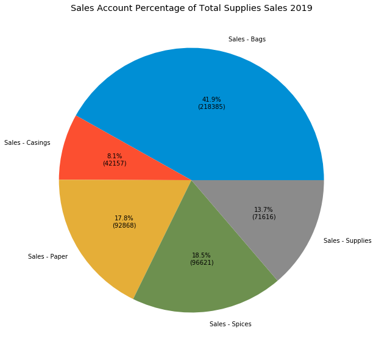

```python
rcParams['figure.figsize'] = 18, 10
pie_chart_df = all_data.copy()
pie_chart_df.Year = pd.to_numeric(pie_chart_df.Year)
pie_chart_df = pie_chart_df[pie_chart_df.Year >= 2019]
pie_chart_df = pie_chart_df.groupby(['Account'])['Amount'].sum().reset_index()
pie_chart_df = pie_chart_df.set_index('Account')
def func(pct, allvals):
    absolute = int(pct/100.*np.sum(allvals))
    return "{:.1f}%\n({:d})".format(pct, absolute)
pyplot.pie(x=pie_chart_df['Amount'], labels=pie_chart_df.index, autopct=lambda pct: func(pct, pie_chart_df))
pyplot.title("Sales Account Percentage of Total Supplies Sales 2019")
pyplot.show()
```

Return to Contents

# Sales - Spices Analysis

- 4.1 ABC Analysis for Sales - Spices
  - 4.1.1 ABC Analysis Takeaway
  - 4.1.2 Account Sales Aggragation
- 4.2. Forecasting and Analysis
  - 4.2.1 Basic Statistics
  - 4.2.2 Moving Average Model
    - 4.2.2.1 Moving Average Analysis
    - 4.2.2.2 Moving Average Takeaway
  - 4.2.3 Simple Exponential Smoothing Model
    - 4.2.3.1 Simple Exponential Smooting Analysis
    - 4.2.3.2 Simple Exponential Smooting Takeaway
  - 4.2.4 Holt-Winters Seasonal Smoothing Model
    - 4.4.4.1 Holt-Winters Seasonal Smoothing Analysis
    - 4.4.4.2 Holt-Winters Seasonal Smoothing Analysis Takeaway
  - 4.2.5 Seasonal ARIMA Model
    - 4.2.5.1 Seasonal ARIMA Analysis
    - 4.2.5.2 Seasonal ARIMA Analysis Takeaway
  - 4.2.6 Combined Forecast Analyasis
    - 4.2.6.1 Combined Forecast Analyasis Takeaway

## ABC Analysis

The ABC Analysis, based on the Pareto Principle (i.e. the 80/20 rule), is useful for selective inventory control, it helps to determine the faster moving/ higher value items. In this case we will be using it to determine the items that have largest Proportion of Usage Value. This value will be used to determine which item will be used for the forecast within the notebook. This helps us filter out the other items that are low value/ slow moving.  
Since there is no historical cost of the items within the data, we will use a simple equation to find the cost of the goods:

$$Cost of Item = Sales Price - (Sales Price*Mark up)$$

The steps for creating an ABC Analysis are as follows:

1. Calculate an annual usage value column

| Notation | Description |
| --- | --- |
| $u_{j}$ | Annual useage value for item j |
| $c_{j}$ | Annual cost for item j |
| $D_{j}$ | Annual demand for item j |

$$u_{j} = c_{j}D_{j}$$

1. Sum the annual useage of all items to calculate total annual usage
2. Calculate the portion of useage value where (% for item j) $$= \frac{u_{j}}{\sum_{j=1}^nu_{j}}$$
3. Add a cumlative percentage column
4. Label item as class A, B, or C based on Pareto Rule (A <= 80%, 80% < B <= 95%, C > 95%)

| Type | Annual Usage Value | Total Annual Usage | Proportion of Usage Value | Cumulative Proportion | Inventory Class |
| --- | --- | --- | --- | --- | --- |
| L010C | 15970.15 | 94142.39001 | 0.169638 | 0.169638 | A |
| L114C | 8383.10 | 94142.39001 | 0.089047 | 0.258685 | A |
| L110C | 4519.65 | 94142.39001 | 0.048009 | 0.306694 | A |
| L109C | 3795.11 | 94142.39001 | 0.040312 | 0.347006 | A |
| LB4600 | 3287.51 | 94142.39001 | 0.034921 | 0.381927 | A |

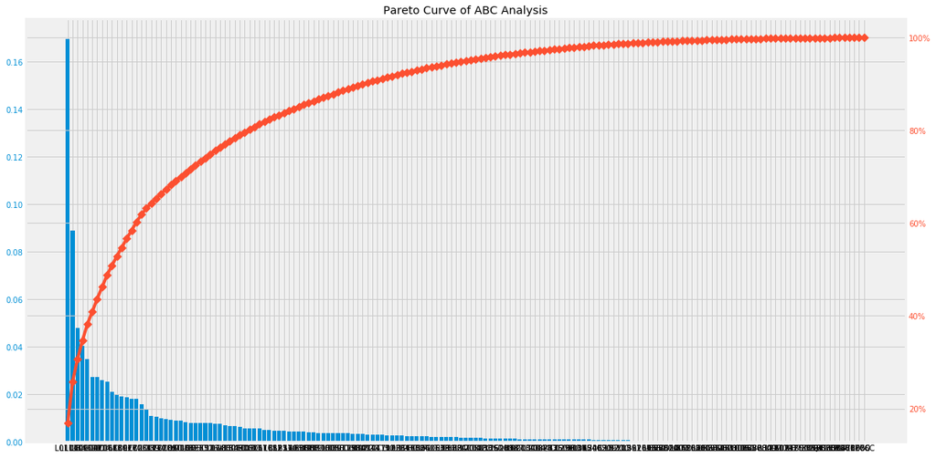

```python
rcParams['figure.figsize'] = 18, 10

mark_up = .3
current_account = 'Sales - Spices'
account_sales = pd.DataFrame()

account_sales = all_data[all_data['Account'] == current_account]
account_sales = account_sales.groupby(['Item', 'Year','Sales Price'])['Qty'].sum().reset_index()
account_sales = account_sales.fillna(0)
account_sales['Qty'] = account_sales['Qty'].astype(float)
account_sales = account_sales.set_index('Item')

account_sales.loc[:, 'Unit Cost'] = account_sales['Sales Price'] - (account_sales['Sales Price']*mark_up)
account_sales.loc[:, 'Annual Usage Value'] = account_sales['Sales Price']*account_sales['Qty']

annual_use_group = pd.DataFrame()
annual_use_group = account_sales.groupby(['Item','Year'])['Annual Usage Value'].sum().reset_index()

item_list = []
for item in annual_use_group['Item']:
    if current_account == 'Sales - Spices':
        item_list.append(item[:item.index("(")])
    elif current_account == 'Sales - Bags':
        item_list.append(item[:item.index("(")])
    elif current_account == 'Sales - Paper':
        item_list.append(item[:item.index("(")])

annual_use_group.loc[:, 'Type'] = item_list

annual_use_group = annual_use_group.groupby(['Year', 'Type'])['Annual Usage Value'].sum().reset_index()
annual_use_group = annual_use_group.set_index('Year')

annual_use_totals = annual_use_group.groupby(['Year'])['Annual Usage Value'].sum().reset_index()
annual_use_totals = annual_use_totals.set_index('Year')
annual_use_totals = annual_use_totals.rename(columns={"Annual Usage Value" : "Total Annual Usage"})

ABC_Class = annual_use_group.join(annual_use_totals)
ABC_Class.loc[:, 'Proportion of Usage Value'] = ABC_Class['Annual Usage Value']/ABC_Class['Total Annual Usage']
ABC_Class.index = pd.to_datetime(ABC_Class.index)
ABC_Class.sort_index()

ABC_Class = ABC_Class[ABC_Class.index == dateutil.parser.parse('2019-01-01')]
ABC_Class = ABC_Class.sort_values(by= ['Proportion of Usage Value'], ascending=False)

ABC_Class.loc[:,'Cumulative Proportion'] = ABC_Class['Proportion of Usage Value'].cumsum()
ABC_Class.loc[ABC_Class['Cumulative Proportion'] <= .8, 'Inventory Class'] = 'A'
ABC_Class.loc[(ABC_Class['Cumulative Proportion'] > .8) & (ABC_Class['Cumulative Proportion'] <= .95),
              'Inventory Class'] = 'B'
ABC_Class.loc[ABC_Class['Cumulative Proportion'] > .95, 'Inventory Class'] = 'C'

ABC_Class_df = ABC_Class.reset_index()
ABC_Class_df = ABC_Class.set_index('Type')

pareto_df = ABC_Class[['Type', 'Proportion of Usage Value']]
pareto_df.reset_index()
pareto_df = pareto_df.set_index('Type')

df = pareto_df
df = df.sort_values(by='Proportion of Usage Value',ascending=False)
df["cumpercentage"] = df['Proportion of Usage Value'].cumsum()/df['Proportion of Usage Value'].sum()*100

fig, ax = pyplot.subplots()
ax.bar(df.index, df['Proportion of Usage Value'], color="C0")
ax2 = ax.twinx()
ax2.plot(df.index, df["cumpercentage"], color="C1", marker="D", ms=7)
ax2.yaxis.set_major_formatter(PercentFormatter())

ax.tick_params(axis="y", colors="C0")
ax2.tick_params(axis="y", colors="C1")

display(HTML(ABC_Class_df.head().to_html()))
pyplot.title("Pareto Curve of ABC Analysis")
pyplot.show()
```

### ABC Analysis Takeaway

As you can see in the pareto curve there are about three items that account for a "significant" portion of sales. But, in reality they only account for a little more than thirty percent of the sales for this account. The unique thing about this account is that there are different blends within the account. So, while the L010C (Pork Sausage Seasoning - case) is the largest cumulative percentage other items in this list could also be from the L010 blend but being sold in packs. So, to correct this before being forecasted the blends must be aggregated.

## Account Sales Aggragation

To correct the sales data before we pass it to the forecasting models the blends must be aggregated. So that the quantity sold is equal to the total number of cases sold.to achieve this the quantities of the cases will be multiplied by 25, then added to the quantity of packs, and then the total will be divided by 25. Finally this number will be rounded up, because you cannot purchase a portion of a case. This will provide us with an accurate estimate of the number of cases sold each month. $$Combined Qty_j= \frac{(Pack Qty_j + (Case Qty_j*25))}{25}$$

This code is also used if the sales account is not spices then the items are aggregated into quantities based on the YearMonth of its Ship-Date.

For visualization purposes the remainder of this analysis will display the demand for **L010 (Pork Sausage Seasoning)** in cases. As this is one of the most seasonal and highest sales volume items.

```
This table shows a sample of the data from the aggregation.
```

| YearMonth | Pack Qty | Case Qty | Combined Qty |
| --- | --- | --- | --- |
| 2010-01 | 33 | 17.0 | 19.0 |
| 2010-02 | 25 | 9.0 | 10.0 |
| 2010-03 | 3 | 5.0 | 6.0 |
| 2010-08 | 3 | 2.0 | 3.0 |
| 2010-10 | 27 | 29.0 | 31.0 |

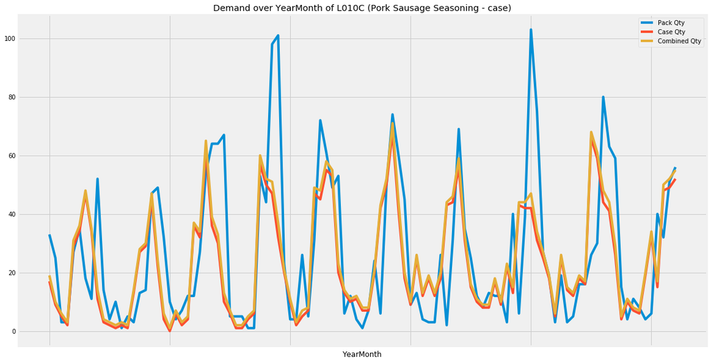

```python
top_item = str(ABC_Class_df.index[0])

entry_list = []
for entry in account_sales.index:
    if top_item in entry:
        if 'MI-SE' in item:
            pass
        else:
            entry_list.append(entry)

entry_list[0]

#the current item in the
current_item = entry_list[0]

#to aggregate the total item sales you need to
item_sales = all_data[all_data['Item'] == current_item]

item_sales = item_sales.groupby(['YearMonth'])['Qty'].sum().reset_index()

item_sales = item_sales.set_index('YearMonth')

if current_account == 'Sales - Spices':
    case_list = []
    pack_list = []

    if ' ' in top_item:
        top_item = top_item[:top_item.index(" ")]

    if 'C' in top_item:
        blend = top_item[:top_item.index("C")]
        for entry in account_sales.index:
            if blend in entry:
                pack_list.append(entry)
        for entry in account_sales.index:
            if top_item in entry:
                case_list.append(entry)

    if 'C' not in top_item:
        case_item = (top_item+'C')
        for entry in account_sales.index:
            if case_item in entry:
                case_list.append(entry)
        for entry in account_sales.index:
            if top_item in entry:
                pack_list.append(entry)

    current_item = pack_list[0]

    item_sales_df = all_data[all_data['Item'] == current_item]
    item_sales_df = item_sales_df[['YearMonth', 'Qty']]
    item_sales_by_date = item_sales_df.groupby(['YearMonth'])['Qty'].sum().reset_index()
    item_sales_by_date_pack = item_sales_by_date.set_index('YearMonth')
    item_sales_by_date_pack = item_sales_by_date_pack.rename(columns={'Qty': 'Pack Qty'})

    current_item = case_list[0]

    item_sales_df = all_data[all_data['Item'] == current_item]
    item_sales_df = item_sales_df[['YearMonth', 'Qty']]
    item_sales_by_date = item_sales_df.groupby(['YearMonth'])['Qty'].sum().reset_index()
    item_sales_by_date_case = item_sales_by_date.set_index('YearMonth')
    item_sales_by_date_case = item_sales_by_date_case.rename(columns={'Qty': 'Case Qty'})

    combined_sales = pd.DataFrame()
    combined_sales = item_sales_by_date_pack.join(item_sales_by_date_case)
    combined_sales = combined_sales.fillna(0)

    combined_sales.loc[:, 'Combined Qty'] = combined_sales['Pack Qty'] + combined_sales['Case Qty']*25
    combined_sales['Combined Qty'] = combined_sales['Combined Qty'].div(25)
    combined_sales['Combined Qty'] = pd.to_numeric(combined_sales['Combined Qty'])
    #rounding the number of cases up
    combined_sales['Combined Qty'] = combined_sales['Combined Qty'].apply(np.ceil)

else:
    combined_sales = item_sales
    combined_sales = combined_sales.rename(columns={'Qty': 'Combined Qty'})

print('This table shows a sample of the data from the aggregation.')
display(HTML(combined_sales.head().to_html()))

combined_sales.plot()
pyplot.title(f"Demand over YearMonth of {current_item}")
pyplot.show()
```

Return to Contents

# Forecasting and Analysis

This section includes:

- 4.2.1 Basic Statistics
- 4.2.2 Moving Average Model
  - 4.2.2.1 Moving Average Analysis
  - 4.2.2.2 Moving Average Takeaway
- 4.2.3 Simple Exponential Smoothing Model
  - 4.2.3.1 Simple Exponential Smooting Analysis
  - 4.2.3.2 Simple Exponential Smooting Takeaway
- 4.2.4 Holt-Winters Seasonal Smoothing Model
  - 4.4.4.1 Holt-Winters Seasonal Smoothing Analysis
  - 4.4.4.2 Holt-Winters Seasonal Smoothing Analysis Takeaway
- 4.2.5 Seasonal ARIMA Model
  - 4.2.5.1 Seasonal ARIMA Analysis
  - 4.2.5.2 Seasonal ARIMA Analysis Takeaway
- 4.2.6 Combined Forecast Analyasis
  - 4.2.6.1 Combined Forecast Analyasis Takeaway

For the analysis of each forecast the actual 2019 data will be compared to the forecasted values. The test to see the accuracy of the forecasts are:

| Notation | Description |
| --- | --- |
| $\bar{y_{i}}$ | mean of the observed data $y $ |
| $\hat{y_{i}}$ | forecasted value for item $y $ |
| $i$ | period |
| $n$ | number of periods |

- Mean Absolute Error

  > "In statistics, mean absolute error (MAE) is a measure of errors between paired observations expressing the same phenomenon. Examples of Y versus X include comparisons of predicted versus observed, subsequent time versus initial time, and one technique of measurement versus an alternative technique of measurement." $$MAE= \frac{\sum_{i=1}^n|y_{i}-\hat{y_{i}}|}{n}$$ https://en.wikipedia.org/wiki/Mean_absolute_error
- Mean Squared Error

  > "In statistics, the mean squared error (MSE) measures the average of the squares of the errors—that is, the average squared difference between the estimated values and the actual value." $$MSE= \frac{1}{n}\sum_{i=1}^n(y_{i}-\hat{y_{i}})^2$$ https://en.wikipedia.org/wiki/Mean_squared_error
- Coefficient of determination or $R^2$

  > "R-squared is a statistical measure of how close the data are to the fitted regression line. It is also known as the coefficient of determination, or the coefficient of multiple determination for multiple regression.  
  > The definition of R-squared is fairly straight-forward; it is the percentage of the response variable variation that is explained by a linear model. Or:  
  > R-squared = Explained variation / Total variation  
  > R-squared is always between 0 and 100%:  
  > - 0% indicates that the model explains none of the variability of the response data around its mean.  
  > - 100% indicates that the model explains all the variability of the response data around its mean.  
  > In general, the higher the R-squared, the better the model fits your data."  
  > https://blog.minitab.com/blog/adventures-in-statistics-2/regression-analysis-how-do-i-interpret-r-squared-and-assess-the-goodness-of-fit

  > The variability of the data can be measures using the sum of squares:
  > If $\bar{y}$ is the mean of the observed data: $$\bar{y}=\frac{1}{n}\sum_{i=1}^ny_{i}$$
  > The total sum of squares(proportional to the variance of the data): $$SS_{tot} = \sum_{i}(y_{i}-\bar{y_{i}})^2$$ The sum of squares of residuals $$SS_{res} = \sum_{i}(y_{i}-\hat{y_{i}})^2$$ Using the most general definition of the coefficient of determination: $$R^2 = 1 - \frac{SS_{res}}{SS_{tot}}$$ https://en.wikipedia.org/wiki/Coefficient_of_determination

## Basic Statistics

Some basic statistics about the data are given below, these are provided to gain insight into the data and its shape.

|  | Pack Qty | Case Qty | Combined Qty |
| --- | --- | --- | --- |
| count | 105.000000 | 105.000000 | 105.000000 |
| mean | 26.533333 | 23.333333 | 25.009524 |
| std | 25.255261 | 18.262333 | 18.835572 |
| min | 1.000000 | 0.000000 | 1.000000 |
| 25% | 5.000000 | 8.000000 | 9.000000 |
| 50% | 16.000000 | 18.000000 | 19.000000 |
| 75% | 44.000000 | 41.000000 | 43.000000 |
| max | 103.000000 | 68.000000 | 71.000000 |

```
The average demand per YearMonth is 25.00952380952381
The median demand per YearMonth is 19.0
The maximum demand per YearMonth is 71.0
The minimum demand per YearMonth is 1.0
The range of demand per YearMonth is 70.0
The Interquartile Range of demand per YearMonthis 34.0
The Standard Deviation of demand per YearMonth is 18.835571522487836
```

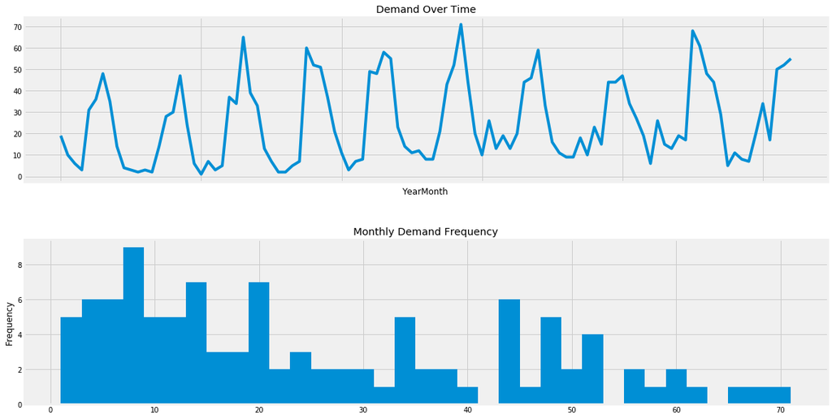

```python
display(HTML(combined_sales.describe().to_html()))

mean = combined_sales['Combined Qty'].mean()
print(f'The average demand per YearMonth is {mean}')
median = combined_sales['Combined Qty'].median()
print (f'The median demand per YearMonth is {median}')
data_max = combined_sales['Combined Qty'].max()
data_min = combined_sales['Combined Qty'].min()
data_range = data_max - data_min
print(f'The maximum demand per YearMonth is {data_max}')
print(f'The minimum demand per YearMonth is {data_min}')
print(f'The range of demand per YearMonth is {data_range}')
inter_quartile_range = stats.iqr(combined_sales['Combined Qty'])
print (f'The Interquartile Range of demand per YearMonthis {inter_quartile_range}')
std_dev = combined_sales['Combined Qty'].std()
print (f'The Standard Deviation of demand per YearMonth is {std_dev}')

fig, axs = pyplot.subplots(2,1)
combined_sales_df = combined_sales['Combined Qty']
combined_sales_df.plot(ax=axs[0], title= 'Demand Over Time');

combined_sales['Combined Qty'].plot(bins= 35, kind= 'hist', title ='Monthly Demand Frequency', ax=axs[1])
pyplot.subplots_adjust(hspace=.35)
pyplot.show()
```

Return to Contents

## Moving Average Model

The first forecast model that I have chosen is the simple moving average model. This model uses the previous $m$ data points and finds the average of those m periods. The average is then used as the forecast for the next year of sales. This is a naive approach to forecasting as it only provides one value for a given forecast. The equation to find a simple moving average is:

| Notation | Description |
| --- | --- |
| $\hat{y_{i}}$ | forecasted value for item $y $ |
| $m$ | number of periods to forecast |
| $i$ | period |
| $y_{i}$ | value of $y$ in period $i$ |

$$\hat{y_{i}}= \frac{1}m {\sum_{j=i-m}^{i-1}}y_{i} = (y_{i-m} +...+y_{i-1})/m$$

For the analyasis of this model the value in the first month of the forecast period is set as the forecast value for the remaing 11 periods.

|  | Case Qty | Combined Qty | 2_Month | 3_Month | 4_Month | 5_Month | 6_Month | 7_Month | 8_Month | 9_Month | 10_Month | 11_Month | 12_Month |
| --- | --- | --- | --- | --- | --- | --- | --- | --- | --- | --- | --- | --- | --- |
| 2019-01 | 44.0 | 48.0 | 54.5 | 59.0 | 48.5 | 42.6 | 37.666667 | 34.428571 | 33.375 | 30.333333 | 29.2 | 29.0 | 29.416667 |
| 2019-02 | 44.0 | 48.0 | 54.5 | 59.0 | 48.5 | 42.6 | 37.666667 | 34.428571 | 33.375 | 30.333333 | 29.2 | 29.0 | 29.416667 |
| 2019-03 | 44.0 | 48.0 | 54.5 | 59.0 | 48.5 | 42.6 | 37.666667 | 34.428571 | 33.375 | 30.333333 | 29.2 | 29.0 | 29.416667 |
| 2019-04 | 44.0 | 48.0 | 54.5 | 59.0 | 48.5 | 42.6 | 37.666667 | 34.428571 | 33.375 | 30.333333 | 29.2 | 29.0 | 29.416667 |
| 2019-05 | 44.0 | 48.0 | 54.5 | 59.0 | 48.5 | 42.6 | 37.666667 | 34.428571 | 33.375 | 30.333333 | 29.2 | 29.0 | 29.416667 |
| 2019-06 | 44.0 | 48.0 | 54.5 | 59.0 | 48.5 | 42.6 | 37.666667 | 34.428571 | 33.375 | 30.333333 | 29.2 | 29.0 | 29.416667 |
| 2019-07 | 44.0 | 48.0 | 54.5 | 59.0 | 48.5 | 42.6 | 37.666667 | 34.428571 | 33.375 | 30.333333 | 29.2 | 29.0 | 29.416667 |
| 2019-08 | 44.0 | 48.0 | 54.5 | 59.0 | 48.5 | 42.6 | 37.666667 | 34.428571 | 33.375 | 30.333333 | 29.2 | 29.0 | 29.416667 |
| 2019-09 | 44.0 | 48.0 | 54.5 | 59.0 | 48.5 | 42.6 | 37.666667 | 34.428571 | 33.375 | 30.333333 | 29.2 | 29.0 | 29.416667 |
| 2019-10 | 44.0 | 48.0 | 54.5 | 59.0 | 48.5 | 42.6 | 37.666667 | 34.428571 | 33.375 | 30.333333 | 29.2 | 29.0 | 29.416667 |
| 2019-11 | 44.0 | 48.0 | 54.5 | 59.0 | 48.5 | 42.6 | 37.666667 | 34.428571 | 33.375 | 30.333333 | 29.2 | 29.0 | 29.416667 |
| 2019-12 | 44.0 | 48.0 | 54.5 | 59.0 | 48.5 | 42.6 | 37.666667 | 34.428571 | 33.375 | 30.333333 | 29.2 | 29.0 | 29.416667 |

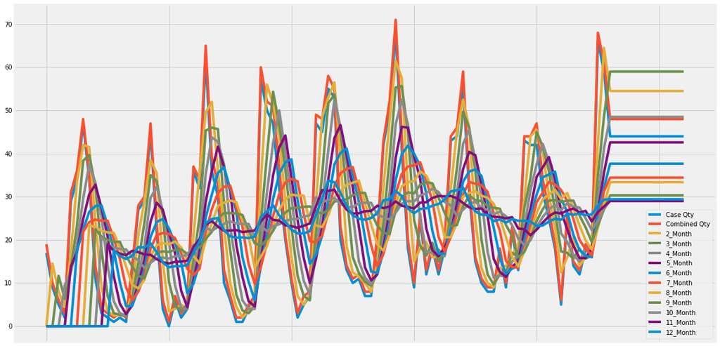

```python
rcParams['figure.figsize'] = 18, 10
if current_account == 'Sales - Spices':
    moving_average_df = combined_sales.copy()
    moving_average_df = moving_average_df.drop(columns=['Pack Qty'])

else:
    moving_average_df = combined_sales.copy()

month_list = [str(i) for i in range(2, 13)]
for month in month_list:
    num_months = int(month)
    col_name = (month+ '_' + 'Month')
    moving_average = combined_sales.rolling(num_months).mean()
    moving_average = moving_average.rename(columns={"Combined Qty": f"{num_months}Month"})
    moving_average_list = moving_average[f'{month}Month'].values.tolist()
    moving_average_df[col_name] = moving_average_list


MA_df = moving_average_df[:'2018-12']

moving_average_forecast = moving_average_df.loc['2018-12']
moving_average_forecast = moving_average_forecast.to_frame()
moving_average_forecast = moving_average_forecast.T
forecast_values_list = list(moving_average_forecast.loc['2018-12'])

forecast_list = []
for month in range(0, len(moving_average_df['2019-01':])):
    forecast_list.append(forecast_values_list)
app_df = pd.DataFrame(forecast_list, columns= list(moving_average_forecast.columns),
                      index=(list(moving_average_df['2019-01':].index)))
app_df

MA_df = MA_df.append(app_df)
MA_df = MA_df.fillna(0)

display(HTML(MA_df['2019-01':].to_html()))

MA_df.plot()
pyplot.show()
```

## Moving Average Analysis

```python
forecast_analysis = MA_df['2019-01':]
columns_list = list(forecast_analysis.columns)
moving_average_month_list = columns_list[columns_list.index('Combined Qty')+1:]

accuracy_df = pd.DataFrame(columns=['MAE','MSE','$R^2$'], index=moving_average_month_list)


MAE_list = []
for month in moving_average_month_list:
    error = sk.mean_absolute_error(forecast_analysis['Combined Qty'], forecast_analysis[month])
    MAE_list.append(error)
accuracy_df['MAE']= MAE_list

MSE_list = []
for month in moving_average_month_list:
    error = sk.mean_squared_error(forecast_analysis['Combined Qty'], forecast_analysis[month])
    MSE_list.append(error)
accuracy_df['MSE']= MSE_list

r2_list = []
for month in moving_average_month_list:
    error = sk.r2_score(forecast_analysis['Combined Qty'], forecast_analysis[month])
    r2_list.append(error)
accuracy_df['$R^2$']= r2_list

MAE_min = accuracy_df['MAE'].min()

new = accuracy_df.loc[(accuracy_df['MAE'] == MAE_min)]
a = list(new.index)
MAE_min_month = a[0]

MSE_min = accuracy_df['MSE'].min()

new = accuracy_df.loc[(accuracy_df['MSE'] == MSE_min)]
b = list(new.index)
MSE_min_month = a[0]

R2_max = accuracy_df['$R^2$'].max()

new = accuracy_df.loc[(accuracy_df['$R^2$'] == R2_max)]
a = list(new.index)
R2_max_month = a[0]

comparison_list = []
comparison_list.append(MAE_min_month)
comparison_list.append(MSE_min_month)
comparison_list.append(R2_max_month)
comparison_list

result = len(comparison_list) > 0 and all(elem == comparison_list[0] for elem in comparison_list)
if result:
    winner = comparison_list[0]
else:
    winner = R2_max_month

print(f'As you can see in the table below moving average that has the lowest Mean Absolute Error is {MAE_min_month} with a value of {MAE_min}.')
print(f'The moving average with the lowest Mean Square Error is {MSE_min_month} with a value of {MSE_min}.')
print(f'The moving average with the largest R square value is {R2_max_month}  with a value of {R2_max}.')
print(f'The most accurate moving average forecast is {winner}.')
accuracy_df

MA_winner_df = forecast_analysis[winner].to_frame()
MA_winner_df.columns = [f'Moving Average {winner}']
MA_act_list = list(moving_average_df['Case Qty'].values)
MA_act_list = MA_act_list[-12:]
MA_winner_df['Actual'] = list(MA_act_list)
MA_winner_df = MA_winner_df[['Actual', f'Moving Average {winner}']]

display(HTML(accuracy_df.to_html()))

print(f'The values of the forecast that produced the best scores are:')
display(HTML(MA_winner_df.to_html()))
```

```
As you can see in the table below moving average that has the lowest Mean Absolute Error is 4_Month with a value of 0.5.
The moving average with the lowest Mean Square Error is 4_Month with a value of 0.25.
The moving average with the largest R square value is 2_Month  with a value of 0.0.
The most accurate moving average forecast is 2_Month.
```

|  | MAE | MSE | $R^2$ |
| --- | --- | --- | --- |
| 2_Month | 6.500000 | 42.250000 | 0.0 |
| 3_Month | 11.000000 | 121.000000 | 0.0 |
| 4_Month | 0.500000 | 0.250000 | 0.0 |
| 5_Month | 5.400000 | 29.160000 | 0.0 |
| 6_Month | 10.333333 | 106.777778 | 0.0 |
| 7_Month | 13.571429 | 184.183673 | 0.0 |
| 8_Month | 14.625000 | 213.890625 | 0.0 |
| 9_Month | 17.666667 | 312.111111 | 0.0 |
| 10_Month | 18.800000 | 353.440000 | 0.0 |
| 11_Month | 19.000000 | 361.000000 | 0.0 |
| 12_Month | 18.583333 | 345.340278 | 0.0 |

```
The values of the forecast that produced the best scores are:
```

|  | Actual | Moving Average 2_Month |
| --- | --- | --- |
| 2019-01 | 41.0 | 54.5 |
| 2019-02 | 26.0 | 54.5 |
| 2019-03 | 4.0 | 54.5 |
| 2019-04 | 10.0 | 54.5 |
| 2019-05 | 7.0 | 54.5 |
| 2019-06 | 6.0 | 54.5 |
| 2019-07 | 19.0 | 54.5 |
| 2019-08 | 33.0 | 54.5 |
| 2019-09 | 15.0 | 54.5 |
| 2019-10 | 48.0 | 54.5 |
| 2019-11 | 49.0 | 54.5 |
| 2019-12 | 52.0 | 54.5 |

## Moving Average Analysis Takeaway

This method of forecasting for this dataset is inherently flawed. The reason the forecast for 2018-12 was then placed as the value for the next year is to show how simple the method is. It does not consider any of the historical data except for the $m$ number of periods. This means once the level is set the forecast will remain at that value until more data is inputted into the model.

Return to Contents

## Simple Exponential Smoothing Model

> "The simplest of the exponentially smoothing methods is naturally called simple exponential smoothing (SES)13. This method is suitable for forecasting data with no clear trend or seasonal pattern."  
> "Forecasts are calculated using weighted averages, where the weights decrease exponentially as observations come from further in the past — the smallest weights are associated with the oldest observations:  
> https://otexts.com/fpp2/ses.html

| Notation | Description |
| --- | --- |
| $\hat{y}$ | forecasted value for item $y$ |
| $\alpha$ | smoothing constant 0$\leq$$\alpha$$\leq$1 |
| $T$ | period |

$$\hat{y}_{T+1|T}=\alpha y_{T}+\alpha (1-\alpha)y_{T-1}+\alpha (1-\alpha)^2 y_{T-1}+...$$

| YearMonth | Actual | α = 0.2 | α = 0.4 | α = 0.6 |
| --- | --- | --- | --- | --- |
| 2019-01 | 44.0 | 38.126622 | 47.378103 | 51.063576 |
| 2019-02 | 29.0 | 38.126622 | 47.378103 | 51.063576 |
| 2019-03 | 5.0 | 38.126622 | 47.378103 | 51.063576 |
| 2019-04 | 11.0 | 38.126622 | 47.378103 | 51.063576 |
| 2019-05 | 8.0 | 38.126622 | 47.378103 | 51.063576 |
| 2019-06 | 7.0 | 38.126622 | 47.378103 | 51.063576 |
| 2019-07 | 20.0 | 38.126622 | 47.378103 | 51.063576 |
| 2019-08 | 34.0 | 38.126622 | 47.378103 | 51.063576 |
| 2019-09 | 17.0 | 38.126622 | 47.378103 | 51.063576 |
| 2019-10 | 50.0 | 38.126622 | 47.378103 | 51.063576 |
| 2019-11 | 52.0 | 38.126622 | 47.378103 | 51.063576 |
| 2019-12 | 55.0 | 38.126622 | 47.378103 | 51.063576 |

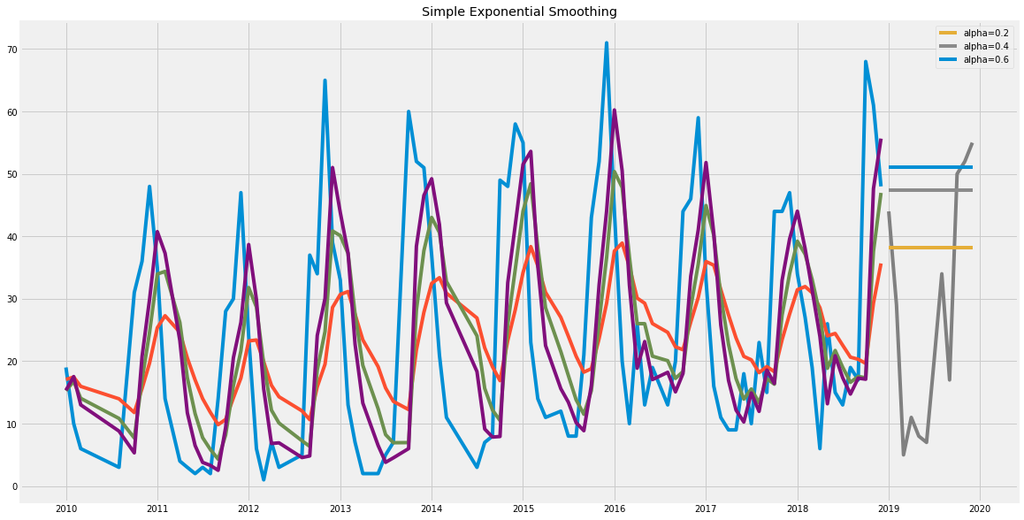

```python
alpha_1 = .2
alpha_2 = .4
alpha_3 = .6

df = combined_sales_df.copy()
length = (len(combined_sales_df['2019-01': '2019-12']))
lengtha = (len(combined_sales_df['2019-01': '2019-12'])-1)
train = df.iloc[:-length]
test = df.iloc[-length:]
train.index = pd.to_datetime(train.index)
test.index = pd.to_datetime(test.index)
pred = test.copy()

model = SimpleExpSmoothing(np.asarray(train))
model._index = pd.to_datetime(train.index)

fit1 = model.fit(smoothing_level=alpha_1)
pred1 = fit1.forecast(lengtha)
fit2 = model.fit(smoothing_level=alpha_2)
pred2 = fit2.forecast(lengtha)
fit3 = model.fit(smoothing_level=alpha_3)
pred3 = fit3.forecast(lengtha)

SES_pred_df = pd.DataFrame(columns=['Actual', f'\u03B1 = {alpha_1}',
                                        f'\u03B1 = {alpha_2}', f'\u03B1 = {alpha_3}'],
                               index=combined_sales_df['2019-01':'2019-12'].index)


Act_list = list(combined_sales_df['2019-01': '2019-12'])

al_1_list = list(pred1)
al_2_list = list(pred2)
al_3_list = list(pred3)

SES_pred_df['Actual']= Act_list
SES_pred_df[f'\u03B1 = {alpha_1}']= al_1_list
SES_pred_df[f'\u03B1 = {alpha_2}']= al_2_list
SES_pred_df[f'\u03B1 = {alpha_3}']= al_3_list

display(HTML(SES_pred_df.to_html()))

fig, ax = pyplot.subplots(figsize=(18, 10))
ax.plot(train.index[:], train.values[:])
ax.plot(test.index, test.values, color="gray")
for p, f in zip((pred1, pred2, pred3),(fit1, fit2, fit3)):
    ax.plot(train.index[:], f.fittedvalues[:])
    ax.plot(test.index, p, label="alpha="+str(f.params['smoothing_level'])[:3])
pyplot.title("Simple Exponential Smoothing")
pyplot.legend();
```

## Simple Exponential Smoothing Analysis

```python
forecast_analysis = SES_pred_df
columns_list = list(SES_pred_df.columns)
moving_average_month_list = columns_list[1:]

SES_accuracy_df = pd.DataFrame(columns=['MAE','MSE','$R^2$'], index=moving_average_month_list)


MAE_list = []
for month in moving_average_month_list:
    error = sk.mean_absolute_error(SES_pred_df['Actual'], forecast_analysis[month])
    MAE_list.append(error)
SES_accuracy_df['MAE']= MAE_list

MSE_list = []
for month in moving_average_month_list:
    error = sk.mean_squared_error(SES_pred_df['Actual'], forecast_analysis[month])
    MSE_list.append(error)
SES_accuracy_df['MSE']= MSE_list

r2_list = []
for month in moving_average_month_list:
    error = sk.r2_score(SES_pred_df['Actual'], forecast_analysis[month])
    r2_list.append(error)
SES_accuracy_df['$R^2$']= r2_list

MAE_min = SES_accuracy_df['MAE'].min()

new = SES_accuracy_df.loc[(SES_accuracy_df['MAE'] == MAE_min)]
a = list(new.index)
MAE_min_month = a[0]

MSE_min = SES_accuracy_df['MSE'].min()

new = SES_accuracy_df.loc[(SES_accuracy_df['MSE'] == MSE_min)]
b = list(new.index)
MSE_min_month = a[0]

R2_max = SES_accuracy_df['$R^2$'].max()

new = SES_accuracy_df.loc[(SES_accuracy_df['$R^2$'] == R2_max)]
a = list(new.index)
R2_max_month = a[0]

comparison_list = []
comparison_list.append(MAE_min_month)
comparison_list.append(MSE_min_month)
comparison_list.append(R2_max_month)
comparison_list

result = len(comparison_list) > 0 and all(elem == comparison_list[0] for elem in comparison_list)
if result:
    winner = comparison_list[0]
else:
    winner = R2_max_month

print(f'As you can see in the table below moving average that has the lowest Mean Absolute Error is {MAE_min_month} with a value of {MAE_min}.')
print(f'The moving average with the lowest Mean Square Error is {MSE_min_month} with a value of {MSE_min}.')
print(f'The moving average with the largest R square value is {R2_max_month}  with a value of {R2_max}.')
print(f'The most accurate moving average forecast is {winner}.')

SES_winner_df = SES_pred_df[winner].to_frame()

SES_winner_df.columns = [f'Simple Exponential Smoothing {winner}']
SES_act_list = list(SES_pred_df['Actual'].values)
SES_act_list = MA_act_list[-12:]
SES_winner_df['Actual'] = list(SES_act_list)
SES_winner_df = SES_winner_df[['Actual', f'Simple Exponential Smoothing {winner}']]


display(HTML(SES_accuracy_df.to_html()))


print(f'The values of the forecast that produced the best scores are:')
display(HTML(SES_winner_df.to_html()))
```

```
As you can see in the table below moving average that has the lowest Mean Absolute Error is α = 0.2 with a value of 18.54220731696746.
The moving average with the lowest Mean Square Error is α = 0.2 with a value of 436.46622010376603.
The moving average with the largest R square value is α = 0.2  with a value of -0.33453235295868655.
The most accurate moving average forecast is α = 0.2.
```

|  | MAE | MSE | $R^2$ |
| --- | --- | --- | --- |
| α = 0.2 | 18.542207 | 436.466220 | -0.334532 |
| α = 0.4 | 22.189051 | 715.596269 | -1.187996 |
| α = 0.6 | 24.209051 | 874.470918 | -1.673769 |

```
The values of the forecast that produced the best scores are:
```

| YearMonth | Actual | Simple Exponential Smoothing α = 0.2 |
| --- | --- | --- |
| 2019-01 | 41.0 | 38.126622 |
| 2019-02 | 26.0 | 38.126622 |
| 2019-03 | 4.0 | 38.126622 |
| 2019-04 | 10.0 | 38.126622 |
| 2019-05 | 7.0 | 38.126622 |
| 2019-06 | 6.0 | 38.126622 |
| 2019-07 | 19.0 | 38.126622 |
| 2019-08 | 33.0 | 38.126622 |
| 2019-09 | 15.0 | 38.126622 |
| 2019-10 | 48.0 | 38.126622 |
| 2019-11 | 49.0 | 38.126622 |
| 2019-12 | 52.0 | 38.126622 |

## Simple Exponential Smoothing Analysis Takeaway

Similarly, to the simple moving average the Simple Exponential Smoothing model uses the one value found and projects it for the next year. This forecast would need to be recalculated each month to get a more accurate forecast. This model can be further optimized as you will see in the next model.  
The winning model was the model that used an $\alpha$ value of 0.2. In my opinion this is because as the alpha value increases it increases the forecasted value for each period. So, the model that produces the smallest value will benefit from having periods with low demand. Using a simple eye test this model would does not pass the reduction of inventory test or the reduction of backorder test.

Return to Contents

## Holt-Winter's Seasonal Smoothing Model

> "The Holt-Winters seasonal method comprises the forecast equation and three smoothing equations — one for the level ℓt, one for the trend $b_{t}$, and one for the seasonal component st, with corresponding smoothing parameters α, β∗ and γ. We use m to denote the frequency of the seasonality, i.e., the number of seasons in a year. For example, for quarterly data $m$=4, and for monthly data $m$=12.  
> There are two variations to this method that differ in the nature of the seasonal component. The additive method is preferred when the seasonal variations are roughly constant through the series, while the multiplicative method is preferred when the seasonal variations are changing proportional to the level of the series. With the additive method, the seasonal component is expressed in absolute terms in the scale of the observed series, and in the level equation the series is seasonally adjusted by subtracting the seasonal component. Within each year, the seasonal component will add up to approximately zero. With the multiplicative method, the seasonal component is expressed in relative terms (percentages), and the series is seasonally adjusted by dividing through by the seasonal component. Within each year, the seasonal component will sum up to approximately $m$."

| Notation | Description |
| --- | --- |
| $\hat{y}$ | forecasted value for item $y$ |
| $m$ | number of seasons in a year |
| $\ell$ | smoothing level |
| $b$ | trend smoothing equation |
| $s$ | seasonal smoothing |
| $\alpha$ | period smoothinh |

> Additive:

$$\hat{y}_{t+h|t} = \ell_{t} + hb_{t} + s_{t+h-m(k+1)}$$$$\ell_{t} = \alpha(y_{t} - s_{t-m}) + (1 - \alpha)(\ell_{t-1} + b_{t-1})$$$$b_{t} = \beta^*(\ell_{t} - \ell_{t-1}) + (1 - \beta^*)b_{t-1}$$$$s_{t} = \gamma (y_{t}-\ell_{t-1}-b_{t-1}) + (1-\gamma)s_{t-m}$$

> Multiplicative:

$$\hat{y}_{t+h|t} = (\ell_{t} + hb_{t})s_{t+h-m(k+1)}$$$$\ell_{t} = \alpha \frac{y_{t}}{s_{t-m}} + (1 - \alpha)(\ell_{t-1} + b_{t-1})$$$$b_{t} = \beta^*(\ell_{t}-\ell_{t-1}) + (1 - \beta^*)b_{t-1}$$$$s_{t} = \gamma \frac{y_{t}}{(\ell_{t-1} + b_{t-1})} + (1 - \gamma)s_{t-m}$$

https://otexts.com/fpp2/holt-winters.html

```
                            OLS Regression Results
==============================================================================
Dep. Variable:           Combined Qty   R-squared:                       0.451
Model:                            OLS   Adj. R-squared:                  0.445
Method:                 Least Squares   F-statistic:                     74.76
Date:                Fri, 24 Apr 2020   Prob (F-statistic):           1.73e-13
Time:                        15:48:34   Log-Likelihood:                -246.74
No. Observations:                  93   AIC:                             497.5
Df Residuals:                      91   BIC:                             502.5
Df Model:                           1
Covariance Type:            nonrobust
==============================================================================
                 coef    std err          t      P>|t|      [0.025      0.975]
------------------------------------------------------------------------------
const         19.5566      0.714     27.371      0.000      18.137      20.976
x1             0.1160      0.013      8.646      0.000       0.089       0.143
==============================================================================
Omnibus:                        3.595   Durbin-Watson:                   0.160
Prob(Omnibus):                  0.166   Jarque-Bera (JB):                3.296
Skew:                           0.461   Prob(JB):                        0.192
Kurtosis:                       3.003   Cond. No.                         106.
==============================================================================

Warnings:
[1] Standard Errors assume that the covariance matrix of the errors is correctly specified.
```

| YearMonth | Actual | Additive | Multiplicative |
| --- | --- | --- | --- |
| 2019-01-01 | 44.0 | 18.899691 | 26.567594 |
| 2019-02-01 | 29.0 | 41.710539 | 30.807544 |
| 2019-03-01 | 5.0 | 32.098295 | 33.769786 |
| 2019-04-01 | 11.0 | 28.986924 | 27.873535 |
| 2019-05-01 | 8.0 | 37.264789 | 34.006379 |
| 2019-06-01 | 7.0 | 30.706438 | 33.345606 |
| 2019-07-01 | 20.0 | 77.004313 | 56.335060 |
| 2019-08-01 | 34.0 | 65.575052 | 55.996443 |
| 2019-09-01 | 17.0 | 75.176029 | 62.860601 |
| 2019-10-01 | 50.0 | 62.018620 | 54.077586 |
| 2019-11-01 | 52.0 | 47.565581 | 47.260476 |
| 2019-12-01 | 55.0 | 36.237266 | 45.907326 |

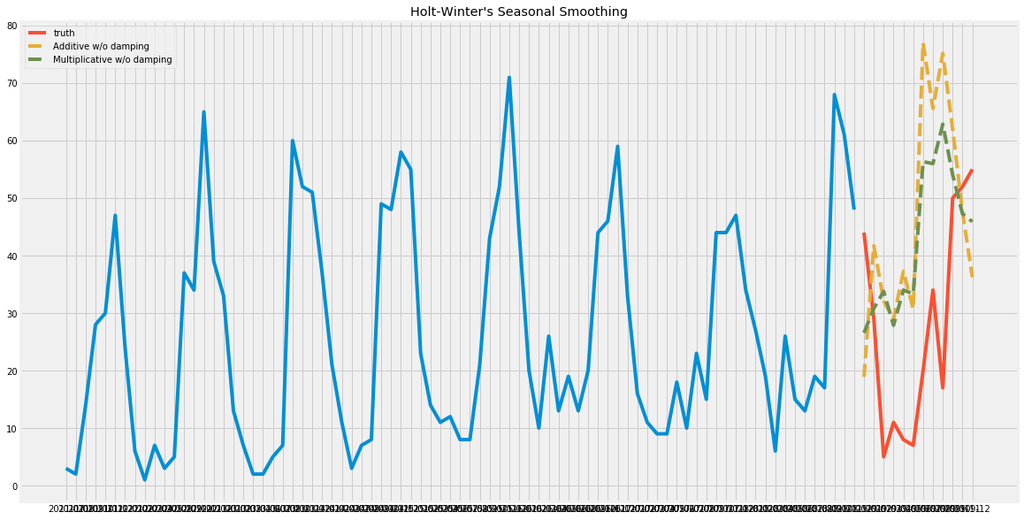

```python
df = combined_sales_df.copy()
length = (len(combined_sales_df['2019-01':]))
lengtha = (len(combined_sales_df['2019-01': '2019-12']))
train = df.iloc[:-length]
test = df.iloc[-length:]
train.index = pd.DatetimeIndex(train.index).to_period('M')
test.index = pd.DatetimeIndex(test.index).to_period('M')
pred = test.copy()
combined_sales_df.index = pd.to_datetime(combined_sales_df.index)
result = sm.tsa.seasonal_decompose(combined_sales_df, model='additive', freq = 12)

x, y = np.arange(len(result.trend.dropna())), result.trend.dropna()
x = sm.add_constant(x)
model = OLS(y, x)
res = model.fit()
print(res.summary())

#pyplot.plot(result.trend.dropna().values, label='trend')
#pyplot.plot([res.params.x1*i + res.params.const for i in np.arange(len(result.trend.dropna()))])
#pyplot.title("Trend and Regression")

model = ExponentialSmoothing(train, trend="add", seasonal="add", seasonal_periods=12).fit(use_boxcox=True)
modela = ExponentialSmoothing(train, trend="add", seasonal="mul", seasonal_periods=12).fit(use_boxcox=True)
#model2 = ExponentialSmoothing(train, trend="add", seasonal="add", seasonal_periods=length, damped=True)
#model2a = ExponentialSmoothing(train, trend="add", seasonal="mul", seasonal_periods=length, damped=False)

fit = model
pred = fit.forecast(12)
fit2 = modela
pred2 = fit2.forecast(12)
#fit3 = model2.fit()
#pred3 = fit3.forecast(length)
#fit4 = model2a.fit()
#pred4 = fit4.forecast(length)

sse1 = np.sqrt(np.mean(np.square(test.values - pred.values)))
sse2 = np.sqrt(np.mean(np.square(test.values - pred2.values)))
#sse3 = np.sqrt(np.mean(np.square(test.values - pred3.values)))
#sse4 = np.sqrt(np.mean(np.square(test.values - pred4.values)))


#HWSS_pred_df = pd.DataFrame(columns=['Actual', 'Additive',
                                       # 'Multiplicative', 'Additive Dam','Multiplicative Dam'],
                               #index=combined_sales_df['2019-01':'2019-12'].index)

HWSS_pred_df = pd.DataFrame(columns=['Actual', 'Additive', 'Multiplicative'],
                            index=combined_sales_df['2019-01':'2019-12'].index)

Act_list = list(combined_sales_df['2019-01':'2019-12'])

al_1_list = list(pred)
al_2_list = list(pred2)
#al_3_list = list(pred3)
#al_4_list = list(pred4)

HWSS_pred_df['Actual']= Act_list
HWSS_pred_df['Additive']= al_1_list
HWSS_pred_df['Multiplicative']= al_2_list
#HWSS_pred_df['Additive Dam']= al_3_list
#HWSS_pred_df['Multiplicative Dam']= al_4_list

display(HTML(HWSS_pred_df.to_html()))

train = df.iloc[:-length]
test = df.iloc[-length:]
fig, ax = pyplot.subplots(figsize=(18, 10))
ax.plot(train.index[length:], train.values[length:]);
ax.plot(test.index, test.values, label='truth');

ax.plot(test.index, pred, linestyle='--', label="Additive w/o damping".format(sse1, fit.aic));
ax.plot(test.index, pred2, linestyle='--', label="Multiplicative w/o damping".format(sse1, fit.aic));
#ax.plot(test.index, pred3, linestyle='--', label="Additive damped".format(sse3, fit3.aic));
#ax.plot(test.index, pred4, linestyle='--', label="Multiplicative damped".format(sse4, fit4.aic));
ax.legend();
ax.set_title("Holt-Winter's Seasonal Smoothing");
```

## Holt-Winter's Seasonal Smoothing Analysis

```python
HWSS_pred_df = HWSS_pred_df.fillna(0)
forecast_analysis = HWSS_pred_df
columns_list = list(HWSS_pred_df.columns)
moving_average_month_list = columns_list[1:]

SES_accuracy_df = pd.DataFrame(columns=['MAE','MSE','$R^2$'], index=moving_average_month_list)


MAE_list = []
for month in moving_average_month_list:
    error = sk.mean_absolute_error(HWSS_pred_df['Actual'], forecast_analysis[month])
    MAE_list.append(error)
SES_accuracy_df['MAE']= MAE_list

MSE_list = []
for month in moving_average_month_list:
    error = sk.mean_squared_error(HWSS_pred_df['Actual'], forecast_analysis[month])
    MSE_list.append(error)
SES_accuracy_df['MSE']= MSE_list

r2_list = []
for month in moving_average_month_list:
    error = sk.r2_score(HWSS_pred_df['Actual'], forecast_analysis[month])
    r2_list.append(error)
SES_accuracy_df['$R^2$']= r2_list

MAE_min = SES_accuracy_df['MAE'].min()

new = SES_accuracy_df.loc[(SES_accuracy_df['MAE'] == MAE_min)]
a = list(new.index)
MAE_min_month = a[0]

MSE_min = SES_accuracy_df['MSE'].min()

new = SES_accuracy_df.loc[(SES_accuracy_df['MSE'] == MSE_min)]
b = list(new.index)
MSE_min_month = a[0]

R2_max = SES_accuracy_df['$R^2$'].max()

new = SES_accuracy_df.loc[(SES_accuracy_df['$R^2$'] == R2_max)]
a = list(new.index)
R2_max_month = a[0]

comparison_list = []
comparison_list.append(MAE_min_month)
comparison_list.append(MSE_min_month)
comparison_list.append(R2_max_month)
comparison_list

result = len(comparison_list) > 0 and all(elem == comparison_list[0] for elem in comparison_list)
if result:
    winner = comparison_list[0]
else:
    winner = R2_max_month

print(f'As you can see in the table below moving average that has the lowest Mean Absolute Error is {MAE_min_month} with a value of {MAE_min}.')
print(f'The moving average with the lowest Mean Square Error is {MSE_min_month} with a value of {MSE_min}.')
print(f'The moving average with the largest R square value is {R2_max_month}  with a value of {R2_max}.')
print(f'The most accurate moving average forecast is {winner}.')

HWSS_winner_df = HWSS_pred_df[winner].to_frame()
HWSS_winner_df.columns = [f'''Holt-Winter's Seasonal Smoothing {winner}''']
HWSS_act_list = list(HWSS_pred_df['Actual'].values)
HWSS_act_list = HWSS_act_list[-12:]
HWSS_winner_df['Actual'] = list(HWSS_act_list)
HWSS_winner_df = HWSS_winner_df[['Actual', f'''Holt-Winter's Seasonal Smoothing {winner}''']]


display(HTML(SES_accuracy_df.to_html()))


print(f'The values of the forecast that produced the best scores are:')
display(HTML(HWSS_winner_df.to_html()))
```

```
As you can see in the table below moving average that has the lowest Mean Absolute Error is Multiplicative with a value of 19.944761901559374.
The moving average with the lowest Mean Square Error is Multiplicative with a value of 568.2530599105404.
The moving average with the largest R square value is Multiplicative  with a value of -0.7374817527415876.
The most accurate moving average forecast is Multiplicative.
```

|  | MAE | MSE | $R^2$ |
| --- | --- | --- | --- |
| Additive | 26.486538 | 951.244237 | -1.908510 |
| Multiplicative | 19.944762 | 568.253060 | -0.737482 |

```
The values of the forecast that produced the best scores are:
```

| YearMonth | Actual | Holt-Winter's Seasonal Smoothing Multiplicative |
| --- | --- | --- |
| 2019-01-01 | 44.0 | 26.567594 |
| 2019-02-01 | 29.0 | 30.807544 |
| 2019-03-01 | 5.0 | 33.769786 |
| 2019-04-01 | 11.0 | 27.873535 |
| 2019-05-01 | 8.0 | 34.006379 |
| 2019-06-01 | 7.0 | 33.345606 |
| 2019-07-01 | 20.0 | 56.335060 |
| 2019-08-01 | 34.0 | 55.996443 |
| 2019-09-01 | 17.0 | 62.860601 |
| 2019-10-01 | 50.0 | 54.077586 |
| 2019-11-01 | 52.0 | 47.260476 |
| 2019-12-01 | 55.0 | 45.907326 |

## Holt-Winter's Seasonal Smoothing Analysis Takeaway

Holt-winter’s offers two methods for seasonality, additive and multiplicative. The additive method is preferred when the data has constant seasonal variations, while multiplicative is preferred when there are seasonal variations that are changing proportional to the level of the series. So, if we look at the historical data, we will see that the seasonal variations are a less than constant, with some seasonal demand starting earlier than others.  
So, with confirmation from the analysis statistics we can see that in fact the multiplicative method was more accurate. This model is also the first one to offer 12 unique forecasts for the upcoming year. This forecast would be helpful in establishing reorder points and inventory levels. While this model still fails the eye test in many periods compared to the actual demand, it’s statistical measures are some of the best yet.

Return to Contents

## Seasonal ARIMA(Auto Regressive Integrated Moving Averge) Model

> "In a multiple regression model, we forecast the variable of interest using a linear combination of predictors. In an autoregression model, we forecast the variable of interest using a linear combination of past values of the variable. The term autoregression indicates that it is a regression of the variable against itself.
> Thus, an autoregressive model of order p can be written as
> $$yt=c+ϕ1yt−1+ϕ2yt−2+⋯+ϕpyt−p+εt$$
> where εt is white noise. This is like a multiple regression but with lagged values of yt as predictors. We refer to this as an AR(p) model, an autoregressive model of order p"
> https://otexts.com/fpp2/AR.html

> "A seasonal ARIMA model is formed by including additional seasonal terms in the ARIMA models we have seen so far. It is written as follows: ARIMA (p,d,q) Non-seasonal part (P,D,Q)m Seasonal part where m= number of observations per year. We use uppercase notation for the seasonal parts of the model, and lowercase notation for the non-seasonal parts of the model."
> $$(1 - \phi_{1}B)~(1 - \Phi_{1}B^{4}) (1 - B) (1 - B^{4})y_{t} = (1 + \theta_{1}B)~ (1 + \Theta_{1}B^{4})\varepsilon_{t}$$
> https://otexts.com/fpp2/seasonal-arima.html

In this model we will be optimizing the (p,d,q) (P,D, Q)12 variables according to the lowest AIC (Akaike information criterion) value.

> “The Akaike information criterion (AIC) is an estimator of out-of-sample prediction error and thereby relative quality of statistical models for a given set of data. Given a collection of models for the data, AIC estimates the quality of each model, relative to each of the other models. Thus, AIC provides a means for model selection.“ https://en.wikipedia.org/wiki/Akaike_information_criterion

The optimization iterates through all options for the variables taking into account the number of periods and the number of records that are being passed to the model. The model with the lowest AIC score is then passed to the remaineder of the code for produce a forecast.

```
                                 Statespace Model Results
==========================================================================================
Dep. Variable:                       Combined Qty   No. Observations:                  105
Model:             SARIMAX(1, 0, 1)x(0, 1, 1, 12)   Log Likelihood                -328.163
Date:                            Fri, 24 Apr 2020   AIC                            664.326
Time:                                    15:48:42   BIC                            673.803
Sample:                                         0   HQIC                           668.123
                                            - 105
Covariance Type:                              opg
==============================================================================
                 coef    std err          z      P>|z|      [0.025      0.975]
------------------------------------------------------------------------------
ar.L1          0.5412      0.130      4.149      0.000       0.286       0.797
ma.L1          0.1599      0.178      0.898      0.369      -0.189       0.509
ma.S.L12      -0.5866      0.135     -4.345      0.000      -0.851      -0.322
sigma2       232.9608     30.912      7.536      0.000     172.375     293.547
===================================================================================
Ljung-Box (Q):                      103.82   Jarque-Bera (JB):                14.19
Prob(Q):                              0.00   Prob(JB):                         0.00
Heteroskedasticity (H):               0.27   Skew:                             0.85
Prob(H) (two-sided):                  0.00   Kurtosis:                         4.19
===================================================================================

Warnings:
[1] Covariance matrix calculated using the outer product of gradients (complex-step).
```

| YearMonth | Actual | Forecasted | lower Combined Qty | upper Combined Qty |
| --- | --- | --- | --- | --- |
| 2019-01-01 | 44.0 | 36.380481 | 6.459843 | 66.301118 |
| 2019-02-01 | 29.0 | 31.896483 | 1.975845 | 61.817121 |
| 2019-03-01 | 5.0 | 22.159762 | -7.760876 | 52.080399 |
| 2019-04-01 | 11.0 | 0.491742 | -29.428896 | 30.412379 |
| 2019-05-01 | 8.0 | 22.795860 | -7.124683 | 52.716403 |
| 2019-06-01 | 7.0 | 7.844292 | -22.072761 | 37.761345 |
| 2019-07-01 | 20.0 | 8.527147 | -21.389816 | 38.444111 |
| 2019-08-01 | 34.0 | 23.499769 | -6.417192 | 53.416731 |
| 2019-09-01 | 17.0 | 26.263296 | -3.653666 | 56.180257 |
| 2019-10-01 | 50.0 | 47.575267 | 17.658306 | 77.492228 |
| 2019-11-01 | 52.0 | 48.341850 | 18.424889 | 78.258812 |
| 2019-12-01 | 55.0 | 49.983548 | 20.066587 | 79.900510 |

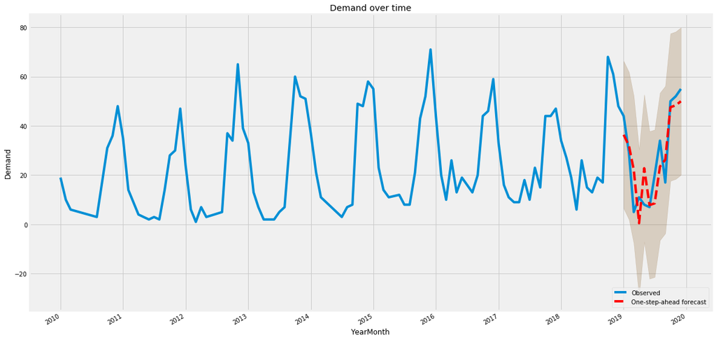

```python
warnings.filterwarnings("ignore")


#AIC Optimization
AIC_values_list = []
AIC_seasonal_params_values_list = []
AIC_params_values_list = []

p = d = q = range(0, 2)
pdq = list(itertools.product(p, d, q))
seasonal_pdq = [(x[0], x[1], x[2], 12) for x in list(itertools.product(p, d, q))]

for param in pdq:
    for param_seasonal in seasonal_pdq:
        mod = sm.tsa.statespace.SARIMAX(combined_sales_df, order=param, seasonal_order=param_seasonal,
                                        enforce_invertibility=False,
                                       enforce_stationarity=False)

        AIC_params_values_list.append(param)
        AIC_seasonal_params_values_list.append(param_seasonal)
        results = mod.fit()
        AIC_values_list.append(results.aic)

AIC_min = min(AIC_values_list)
order_tupe = AIC_params_values_list[AIC_values_list.index(AIC_min)]
seasonal_order = AIC_seasonal_params_values_list[AIC_values_list.index(AIC_min)]

mod = sm.tsa.statespace.SARIMAX(combined_sales_df, order = order_tupe, seasonal_order= seasonal_order,
                                            enforce_stationarity=False,
                                            enforce_invertibility=False)
res = mod.fit(display=False)
print(res.summary())

predict = res.get_prediction()
predict_ci = predict.conf_int()

SARIMAX_pred_df = pd.DataFrame(columns=['Actual', 'Forecasted'],
                               index=combined_sales_df['2019-01':].index)


Act_list = list(combined_sales_df['2019-01':])

y_forecasted = predict.predicted_mean
al_1_list = list(y_forecasted['2019-01-01':])

SARIMAX_pred_df['Actual']= Act_list
SARIMAX_pred_df['Forecasted']= al_1_list

joined_df = SARIMAX_pred_df.join(predict_ci['2019-01-01':])

display(HTML(joined_df.to_html()))

fig, ax = pyplot.subplots(figsize=(18,10))
ax.set(title='Demand over time', xlabel='YearMonth', ylabel='Demand')

combined_sales_df.loc['2010-01-01':].plot(ax=ax, label='Observed')

predict.predicted_mean.loc['2019-01-01':].plot(ax=ax, style='r--', label='One-step-ahead forecast')
ci = predict_ci.loc['2019-01-01':]
ax.fill_between(ci.index, ci.iloc[:,0], ci.iloc[:,1], color='r', alpha=0.1)
ax.fill_between(ci.index, ci.iloc[:,0], ci.iloc[:,1], color='g', alpha=0.1)

legend = ax.legend(loc='lower right')
```

## Seasonal ARIMA Analysis

```python
forecast_analysis = joined_df
columns_list = list(joined_df.columns)
moving_average_month_list = ['Forecasted']

SES_accuracy_df = pd.DataFrame(columns=['MAE','MSE','$R^2$'], index=moving_average_month_list)


MAE_list = []
for month in moving_average_month_list:
    error = sk.mean_absolute_error(joined_df['Actual'], forecast_analysis[month])
    MAE_list.append(error)
SES_accuracy_df['MAE']= MAE_list

MSE_list = []
for month in moving_average_month_list:
    error = sk.mean_squared_error(joined_df['Actual'], forecast_analysis[month])
    MSE_list.append(error)
SES_accuracy_df['MSE']= MSE_list

r2_list = []
for month in moving_average_month_list:
    error = sk.r2_score(joined_df['Actual'], forecast_analysis[month])
    r2_list.append(error)
SES_accuracy_df['$R^2$']= r2_list

MAE_min = SES_accuracy_df['MAE'].min()

new = SES_accuracy_df.loc[(SES_accuracy_df['MAE'] == MAE_min)]
a = list(new.index)
MAE_min_month = a[0]

MSE_min = SES_accuracy_df['MSE'].min()

new = SES_accuracy_df.loc[(SES_accuracy_df['MSE'] == MSE_min)]
b = list(new.index)
MSE_min_month = a[0]

R2_max = SES_accuracy_df['$R^2$'].max()

new = SES_accuracy_df.loc[(SES_accuracy_df['$R^2$'] == R2_max)]
a = list(new.index)
R2_max_month = a[0]

comparison_list = []
comparison_list.append(MAE_min_month)
comparison_list.append(MSE_min_month)
comparison_list.append(R2_max_month)
comparison_list

result = len(comparison_list) > 0 and all(elem == comparison_list[0] for elem in comparison_list)
if result:
    winner = comparison_list[0]
else:
    winner = R2_max_month

print(f'As you can see in the table below moving average that has the lowest Mean Absolute Error is {MAE_min_month} with a value of {MAE_min}.')
print(f'The moving average with the lowest Mean Square Error is {MSE_min_month} with a value of {MSE_min}.')
print(f'The moving average with the largest R square value is {R2_max_month}  with a value of {R2_max}.')
print(f'The most accurate moving average forecast is {winner}.')

SARIMAX_winner_df = joined_df[winner].to_frame()

SARIMAX_winner_df.columns = [f'Seasonal ARIMA {winner}']
SARIMAX_act_list = list(joined_df['Actual'].values)
SARIMAX_act_list = SARIMAX_act_list[-12:]
SARIMAX_winner_df['Actual'] = list(SARIMAX_act_list)
SARIMAX_winner_df = SARIMAX_winner_df[['Actual', f'Seasonal ARIMA {winner}']]



display(HTML(SES_accuracy_df.to_html()))

print(f'The values of the forecast that produced the best scores are:')
display(HTML(SARIMAX_winner_df.to_html()))
```

```
As you can see in the table below moving average that has the lowest Mean Absolute Error is Forecasted with a value of 8.01332397637904.
The moving average with the lowest Mean Square Error is Forecasted with a value of 88.58949372520804.
The moving average with the largest R square value is Forecasted  with a value of 0.7291301363931129.
The most accurate moving average forecast is Forecasted.
```

|  | MAE | MSE | $R^2$ |
| --- | --- | --- | --- |
| Forecasted | 8.013324 | 88.589494 | 0.72913 |

```
The values of the forecast that produced the best scores are:
```

| YearMonth | Actual | Seasonal ARIMA Forecasted |
| --- | --- | --- |
| 2019-01-01 | 44.0 | 36.380481 |
| 2019-02-01 | 29.0 | 31.896483 |
| 2019-03-01 | 5.0 | 22.159762 |
| 2019-04-01 | 11.0 | 0.491742 |
| 2019-05-01 | 8.0 | 22.795860 |
| 2019-06-01 | 7.0 | 7.844292 |
| 2019-07-01 | 20.0 | 8.527147 |
| 2019-08-01 | 34.0 | 23.499769 |
| 2019-09-01 | 17.0 | 26.263296 |
| 2019-10-01 | 50.0 | 47.575267 |
| 2019-11-01 | 52.0 | 48.341850 |
| 2019-12-01 | 55.0 | 49.983548 |

## Seasonal ARIMA Analysis Takeaway

The analysis of the model based on the average of the lower and upper bounds of the forecast. While some of the lower bounds are negative, the average forecast remains above zero. The forecast does have areas where it could improve as it undershoots the low demand forecasts. However, on the other side the higher demand periods are close to being accurate. This fit of the forecast to the true data gives the model a shocking $R^2$ value of .729.

Return to Contents

## Combined Forecasting Analysis

```python
actual_df = combined_sales_df['2019-01-01':].copy()
actual_df = actual_df.to_frame()
forecast_winners_df = pd.DataFrame()


MA_winner_df = MA_winner_df.drop(['Actual'], axis=1)
SES_winner_df = SES_winner_df.drop(['Actual'], axis=1)
HWSS_winner_df = HWSS_winner_df.drop(['Actual'], axis=1)
SARIMAX_winner_df = SARIMAX_winner_df.drop(['Actual'], axis=1)


forecast_winners_df = pd.concat([actual_df, MA_winner_df, SES_winner_df, HWSS_winner_df,
                                 SARIMAX_winner_df], axis=1, sort=False)


forecast_analysis = forecast_winners_df
columns_list = list(forecast_winners_df.columns)
moving_average_month_list = columns_list[1:]

SES_accuracy_df = pd.DataFrame(columns=['MAE','MSE','$R^2$'], index=moving_average_month_list)


MAE_list = []
for month in moving_average_month_list:
    error = sk.mean_absolute_error(forecast_winners_df['Combined Qty'], forecast_analysis[month])
    MAE_list.append(error)
SES_accuracy_df['MAE']= MAE_list

MSE_list = []
for month in moving_average_month_list:
    error = sk.mean_squared_error(forecast_winners_df['Combined Qty'], forecast_analysis[month])
    MSE_list.append(error)
SES_accuracy_df['MSE']= MSE_list

r2_list = []
for month in moving_average_month_list:
    error = sk.r2_score(forecast_winners_df['Combined Qty'], forecast_analysis[month])
    r2_list.append(error)
SES_accuracy_df['$R^2$']= r2_list

MAE_min = SES_accuracy_df['MAE'].min()

new = SES_accuracy_df.loc[(SES_accuracy_df['MAE'] == MAE_min)]
a = list(new.index)
MAE_min_month = a[0]

MSE_min = SES_accuracy_df['MSE'].min()

new = SES_accuracy_df.loc[(SES_accuracy_df['MSE'] == MSE_min)]
b = list(new.index)
MSE_min_month = a[0]

R2_max = SES_accuracy_df['$R^2$'].max()

new = SES_accuracy_df.loc[(SES_accuracy_df['$R^2$'] == R2_max)]
a = list(new.index)
R2_max_month = a[0]

comparison_list = []
comparison_list.append(MAE_min_month)
comparison_list.append(MSE_min_month)
comparison_list.append(R2_max_month)
comparison_list

result = len(comparison_list) > 0 and all(elem == comparison_list[0] for elem in comparison_list)
if result:
    winner = comparison_list[0]
else:
    winner = R2_max_month

display(HTML(forecast_winners_df.to_html()))

print(f'As you can see in the table below moving average that has the lowest Mean Absolute Error is {MAE_min_month} with a value of {MAE_min}.')
print(f'The moving average with the lowest Mean Square Error is {MSE_min_month} with a value of {MSE_min}.')
print(f'The moving average with the largest R square value is {R2_max_month}  with a value of {R2_max}.')
print(f'The most accurate moving average forecast is {winner}.')

forecast_winner_df = forecast_winners_df[winner].to_frame()

forecast_winner_df.columns = [f'Forecast: {winner}']
forecast_act_list = list(forecast_winners_df['Combined Qty'].values)
forecast_act_list = forecast_act_list[-12:]
forecast_winner_df['Actual'] = list(forecast_act_list)
forecast_winner_df = forecast_winner_df[['Actual', f'Forecast: {winner}']]

display(HTML(SES_accuracy_df.to_html()))

print(f'The values of the forecast that produced the best scores are:')
display(HTML(forecast_winner_df.to_html()))
```

| YearMonth | Combined Qty | Moving Average 2_Month | Simple Exponential Smoothing α = 0.2 | Holt-Winter's Seasonal Smoothing Multiplicative | Seasonal ARIMA Forecasted |
| --- | --- | --- | --- | --- | --- |
| 2019-01-01 | 44.0 | 54.5 | 38.126622 | 26.567594 | 36.380481 |
| 2019-02-01 | 29.0 | 54.5 | 38.126622 | 30.807544 | 31.896483 |
| 2019-03-01 | 5.0 | 54.5 | 38.126622 | 33.769786 | 22.159762 |
| 2019-04-01 | 11.0 | 54.5 | 38.126622 | 27.873535 | 0.491742 |
| 2019-05-01 | 8.0 | 54.5 | 38.126622 | 34.006379 | 22.795860 |
| 2019-06-01 | 7.0 | 54.5 | 38.126622 | 33.345606 | 7.844292 |
| 2019-07-01 | 20.0 | 54.5 | 38.126622 | 56.335060 | 8.527147 |
| 2019-08-01 | 34.0 | 54.5 | 38.126622 | 55.996443 | 23.499769 |
| 2019-09-01 | 17.0 | 54.5 | 38.126622 | 62.860601 | 26.263296 |
| 2019-10-01 | 50.0 | 54.5 | 38.126622 | 54.077586 | 47.575267 |
| 2019-11-01 | 52.0 | 54.5 | 38.126622 | 47.260476 | 48.341850 |
| 2019-12-01 | 55.0 | 54.5 | 38.126622 | 45.907326 | 49.983548 |

```
As you can see in the table below moving average that has the lowest Mean Absolute Error is Seasonal ARIMA Forecasted with a value of 8.01332397637904.
The moving average with the lowest Mean Square Error is Seasonal ARIMA Forecasted with a value of 88.58949372520804.
The moving average with the largest R square value is Seasonal ARIMA Forecasted  with a value of 0.7291301363931129.
The most accurate moving average forecast is Seasonal ARIMA Forecasted.
```

|  | MAE | MSE | $R^2$ |
| --- | --- | --- | --- |
| Moving Average 2_Month | 26.916667 | 1047.083333 | -2.201546 |
| Simple Exponential Smoothing α = 0.2 | 18.542207 | 436.466220 | -0.334532 |
| Holt-Winter's Seasonal Smoothing Multiplicative | 19.944762 | 568.253060 | -0.737482 |
| Seasonal ARIMA Forecasted | 8.013324 | 88.589494 | 0.729130 |

```
The values of the forecast that produced the best scores are:
```

| YearMonth | Actual | Forecast: Seasonal ARIMA Forecasted |
| --- | --- | --- |
| 2019-01-01 | 44.0 | 36.380481 |
| 2019-02-01 | 29.0 | 31.896483 |
| 2019-03-01 | 5.0 | 22.159762 |
| 2019-04-01 | 11.0 | 0.491742 |
| 2019-05-01 | 8.0 | 22.795860 |
| 2019-06-01 | 7.0 | 7.844292 |
| 2019-07-01 | 20.0 | 8.527147 |
| 2019-08-01 | 34.0 | 23.499769 |
| 2019-09-01 | 17.0 | 26.263296 |
| 2019-10-01 | 50.0 | 47.575267 |
| 2019-11-01 | 52.0 | 48.341850 |
| 2019-12-01 | 55.0 | 49.983548 |

## Combined Forecasting Analysis Takeaway

With little surprise the most complex model with optimization was the winning forecast. The Seasonal ARIMA model is the model that provides the lowest MAE, the lowest MSE and the highest R^2 value. This places the Seasonal ARIMA model in first with the simple exponential smoothing in second followed by the Holt-Winters and in last the Simple moving average.  
The results of these models prove that forecasts can always be wrong, and that by adding more parameters and data you can find a model that can works for your dataset.

Return to Contents

Advance to Conclusion

# Multi Item Analysis

This is an example of how the code can be used for multiple items in a singular sales account. In this example the ‘Sales-Paper’ sales account is passed to the ABC analysis. After the ABC analysis is complete the code then takes the Items that classified as Inventory type A and then forecasts them according to the Seasonal ARIMA model.

## Multi Item Forecast

| Type | Annual Usage Value | Total Annual Usage | Proportion of Usage Value | Cumulative Proportion | Inventory Class |
| --- | --- | --- | --- | --- | --- |
| HMP0U9550012 | 44838.81 | 92868.88 | 0.482818 | 0.482818 | A |
| HMP0U9550003 | 16114.89 | 92868.88 | 0.173523 | 0.656341 | A |
| HMIWW10x15 | 13433.00 | 92868.88 | 0.144645 | 0.800986 | B |
| HMP0EG12200 | 8114.59 | 92868.88 | 0.087377 | 0.888363 | B |
| HMP09515366 | 1914.04 | 92868.88 | 0.020610 | 0.908973 | B |

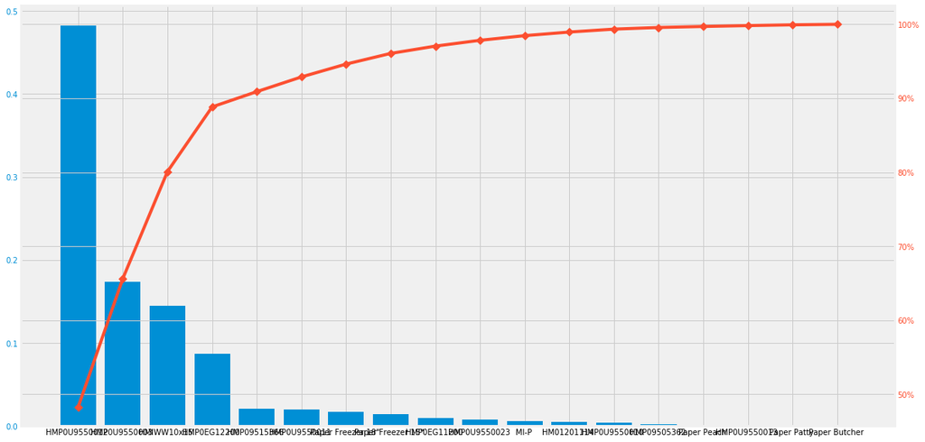

```
According to the ABC invnetory these items will be forecasted:
['HMP0U9550003 (U S 5 1/2 Patty Paper (was H2 5 1/2))', 'HMP0U9550012 (UH 5 1/2" Freezer Patty Paper (was H6 5 1/2))']
Below is the forecat using the Seasonal ARIMA Model:
```

| YearMonth | Item | Actual | Forecasted | lower Combined Qty | upper Combined Qty |
| --- | --- | --- | --- | --- | --- |
| 2019-01-01 | HMP0U9550003 (U S 5 1/2 Patty Paper (was H2 5 ... | 2019-01-01 | 13.276846 | -7.748042e+08 | 7.748043e+08 |
| 2019-02-01 | HMP0U9550003 (U S 5 1/2 Patty Paper (was H2 5 ... | 2019-02-01 | 10.847821 | -7.748042e+08 | 7.748043e+08 |
| 2019-03-01 | HMP0U9550003 (U S 5 1/2 Patty Paper (was H2 5 ... | 2019-03-01 | 11.017542 | -7.748042e+08 | 7.748043e+08 |
| 2019-04-01 | HMP0U9550003 (U S 5 1/2 Patty Paper (was H2 5 ... | 2019-04-01 | 10.763228 | -7.748042e+08 | 7.748043e+08 |
| 2019-05-01 | HMP0U9550003 (U S 5 1/2 Patty Paper (was H2 5 ... | 2019-05-01 | 12.777480 | -7.748042e+08 | 7.748043e+08 |
| 2019-06-01 | HMP0U9550003 (U S 5 1/2 Patty Paper (was H2 5 ... | 2019-06-01 | 20.133955 | -7.748042e+08 | 7.748043e+08 |
| 2019-07-01 | HMP0U9550003 (U S 5 1/2 Patty Paper (was H2 5 ... | 2019-07-01 | 7.402782 | -7.748042e+08 | 7.748043e+08 |
| 2019-08-01 | HMP0U9550003 (U S 5 1/2 Patty Paper (was H2 5 ... | 2019-08-01 | 17.166831 | -7.748042e+08 | 7.748043e+08 |
| 2019-09-01 | HMP0U9550003 (U S 5 1/2 Patty Paper (was H2 5 ... | 2019-09-01 | 13.951738 | -7.748042e+08 | 7.748043e+08 |
| 2019-10-01 | HMP0U9550003 (U S 5 1/2 Patty Paper (was H2 5 ... | 2019-10-01 | 14.205868 | -7.748042e+08 | 7.748043e+08 |
| 2019-11-01 | HMP0U9550003 (U S 5 1/2 Patty Paper (was H2 5 ... | 2019-11-01 | 15.260038 | -7.748042e+08 | 7.748043e+08 |
| 2019-12-01 | HMP0U9550003 (U S 5 1/2 Patty Paper (was H2 5 ... | 2019-12-01 | 6.938574 | -7.748042e+08 | 7.748043e+08 |
| 2019-01-01 | HMP0U9550012 (UH 5 1/2" Freezer Patty Paper (w... | 2019-01-01 | 27.901524 | 4.863353e+00 | 5.093970e+01 |
| 2019-02-01 | HMP0U9550012 (UH 5 1/2" Freezer Patty Paper (w... | 2019-02-01 | 26.830324 | 3.792153e+00 | 4.986850e+01 |
| 2019-03-01 | HMP0U9550012 (UH 5 1/2" Freezer Patty Paper (w... | 2019-03-01 | 30.766183 | 7.728013e+00 | 5.380435e+01 |
| 2019-04-01 | HMP0U9550012 (UH 5 1/2" Freezer Patty Paper (w... | 2019-04-01 | 39.163505 | 1.612590e+01 | 6.220111e+01 |
| 2019-05-01 | HMP0U9550012 (UH 5 1/2" Freezer Patty Paper (w... | 2019-05-01 | 35.914860 | 1.289223e+01 | 5.893749e+01 |
| 2019-06-01 | HMP0U9550012 (UH 5 1/2" Freezer Patty Paper (w... | 2019-06-01 | 42.250888 | 1.922879e+01 | 6.527299e+01 |
| 2019-07-01 | HMP0U9550012 (UH 5 1/2" Freezer Patty Paper (w... | 2019-07-01 | 40.449772 | 1.742769e+01 | 6.347186e+01 |
| 2019-08-01 | HMP0U9550012 (UH 5 1/2" Freezer Patty Paper (w... | 2019-08-01 | 41.240242 | 1.821816e+01 | 6.426232e+01 |
| 2019-09-01 | HMP0U9550012 (UH 5 1/2" Freezer Patty Paper (w... | 2019-09-01 | 30.839268 | 7.817186e+00 | 5.386135e+01 |
| 2019-10-01 | HMP0U9550012 (UH 5 1/2" Freezer Patty Paper (w... | 2019-10-01 | 38.044091 | 1.502201e+01 | 6.106617e+01 |
| 2019-11-01 | HMP0U9550012 (UH 5 1/2" Freezer Patty Paper (w... | 2019-11-01 | 40.913083 | 1.789100e+01 | 6.393517e+01 |
| 2019-12-01 | HMP0U9550012 (UH 5 1/2" Freezer Patty Paper (w... | 2019-12-01 | 30.684872 | 7.662789e+00 | 5.370695e+01 |

```python
rcParams['figure.figsize'] = 18, 10
#set markup
mark_up = .3
current_account = 'Sales - Paper'
account_sales = pd.DataFrame()
#to aggregate the total category sales you need to
account_sales = all_data[all_data['Account'] == current_account]
account_sales = account_sales.groupby(['Item', 'Year','Sales Price'])['Qty'].sum().reset_index()
account_sales = account_sales.fillna(0)
account_sales['Qty'] = account_sales['Qty'].astype(float)
account_sales = account_sales.set_index('Item')
account_sales.loc[:, 'Unit Cost'] = account_sales['Sales Price'] - (account_sales['Sales Price']*mark_up)
account_sales.loc[:, 'Annual Usage Value'] = account_sales['Sales Price']*account_sales['Qty']
annual_use_group = pd.DataFrame()
annual_use_group = account_sales.groupby(['Item','Year'])['Annual Usage Value'].sum().reset_index()

item_list = []
for item in annual_use_group['Item']:
    if current_account == 'Sales - Spices':
        item_list.append(item[:item.index("(")])
    elif current_account == 'Sales - Bags':
        item_list.append(item[:item.index("(")])
    elif current_account == 'Sales - Paper':
        item_list.append(item[:item.index("(")])

annual_use_group.loc[:, 'Type'] = item_list

annual_use_group = annual_use_group.groupby(['Year', 'Type'])['Annual Usage Value'].sum().reset_index()
annual_use_group = annual_use_group.set_index('Year')
annual_use_totals = annual_use_group.groupby(['Year'])['Annual Usage Value'].sum().reset_index()
annual_use_totals = annual_use_totals.set_index('Year')
annual_use_totals = annual_use_totals.rename(columns={"Annual Usage Value" : "Total Annual Usage"})

ABC_Class = annual_use_group.join(annual_use_totals)
ABC_Class.loc[:, 'Proportion of Usage Value'] = ABC_Class['Annual Usage Value']/ABC_Class['Total Annual Usage']
ABC_Class.index = pd.to_datetime(ABC_Class.index)
ABC_Class.sort_index()
ABC_Class = ABC_Class[ABC_Class.index == dateutil.parser.parse('2019-01-01')]
ABC_Class = ABC_Class.sort_values(by= ['Proportion of Usage Value'], ascending=False)
ABC_Class.loc[:,'Cumulative Proportion'] = ABC_Class['Proportion of Usage Value'].cumsum()
ABC_Class.loc[ABC_Class['Cumulative Proportion'] <= .8, 'Inventory Class'] = 'A'
ABC_Class.loc[(ABC_Class['Cumulative Proportion'] > .8) & (ABC_Class['Cumulative Proportion'] <= .95),
              'Inventory Class'] = 'B'
ABC_Class.loc[ABC_Class['Cumulative Proportion'] > .95, 'Inventory Class'] = 'C'

ABC_Class_df = ABC_Class.reset_index()
ABC_Class_df = ABC_Class.set_index('Type')

pareto_df = ABC_Class[['Type', 'Proportion of Usage Value']]
pareto_df.reset_index()
pareto_df = pareto_df.set_index('Type')

df = pareto_df
df = df.sort_values(by='Proportion of Usage Value',ascending=False)
df["cumpercentage"] = df['Proportion of Usage Value'].cumsum()/df['Proportion of Usage Value'].sum()*100


fig, ax = pyplot.subplots()
ax.bar(df.index, df['Proportion of Usage Value'], color="C0")
ax2 = ax.twinx()
ax2.plot(df.index, df["cumpercentage"], color="C1", marker="D", ms=7)
ax2.yaxis.set_major_formatter(PercentFormatter())
ax.tick_params(axis="y", colors="C0")
ax2.tick_params(axis="y", colors="C1")

display(HTML(ABC_Class_df.head().to_html()))

pyplot.show()

months_to_forecast = 12

#to aggregate the total category sales you need to
ABC_list = ['A']

all_items_to_forecast = ABC_Class_df[ABC_Class_df['Inventory Class'].isin(ABC_list)]

entry_list = []
case_list = []
pack_list = []
case_sales = pd.DataFrame()
packs = pd.DataFrame()
all_items_to_forecast_list = list(all_items_to_forecast.index)
combined_sales = pd.DataFrame()

for item in all_items_to_forecast_list:
    for entry in account_sales.index:
        if item in entry:
            if 'MI-SE' in item:
                pass
            else:
                entry_list.append(entry)


entry_list = np.unique(entry_list)

item_sales = all_data.loc[all_data['Item'].isin(entry_list)]
item_sales = item_sales.groupby(['Item', 'YearMonth','Sales Price'])['Qty'].sum().reset_index()
item_sales = item_sales.fillna(0)
item_sales['Qty'] = item_sales['Qty'].astype(float)
item_sales.loc[:, 'Unit Cost'] = item_sales['Sales Price'] - (item_sales['Sales Price']*mark_up)
item_sales.loc[:, 'Annual Usage Value'] = item_sales['Sales Price']*item_sales['Qty']

item_sales_group = pd.DataFrame()
item_sales_group = item_sales.groupby(['Item','YearMonth'])['Qty'].sum().reset_index()

item_list = []
for item in item_sales_group['Item']:
    if current_account == 'Sales - Spices':
        item_list.append(item[:item.index(" (")])
    elif current_account == 'Sales - Bags':
        item_list.append(item[:item.index(" (")])
    elif current_account == 'Sales - Paper':
        item_list.append(item[:item.index(" (")])

item_sales_group.loc[:, 'Type'] = item_list

if current_account == 'Sales - Spices':

    item_lista = []
    for item in item_sales_group['Type']:
        if 'C' in item:
            item_lista.append(item[:item.index('C')])
        else:
            item_lista.append(item)

    item_sales_group.loc[:, 'Blend'] = item_lista
    item_sales_group = item_sales_group.groupby(['YearMonth', 'Type', 'Blend'])['Qty'].sum().reset_index()
    item_sales_group['RowNumber'] = list(range(len(item_sales_group)))
    item_sales_group = item_sales_group.set_index('RowNumber')

    case_sales = item_sales_group[item_sales_group['Type'].str.contains("C")]
    case_sales.loc[:,'Packs'] = case_sales['Qty']*25
    case_sales = case_sales.groupby(['YearMonth', 'Blend'])['Packs'].sum().reset_index()

    case_sales['uqid'] = case_sales['YearMonth'] + case_sales['Blend']
    case_sales = case_sales.rename(columns={'Packs':'Qty'})
    case_sales = case_sales.drop(['YearMonth'], axis=1)
    case_sales = case_sales.set_index('uqid')

    packs = item_sales_group[~item_sales_group.isin(case_sales)].dropna()
    packs = packs.groupby(['YearMonth', 'Blend'])['Qty'].sum().reset_index()
    packs['uqid'] = packs['YearMonth'] + packs['Blend']
    packs = packs.drop(['YearMonth'], axis=1)
    packs = packs.set_index('uqid')


    combined_sales = case_sales.append(packs)
    combined_sales = combined_sales.fillna(0)
    combined_sales = combined_sales.reset_index()
    combined_sales = combined_sales.groupby(['uqid', 'Blend'])['Qty'].sum().reset_index()

    new = combined_sales['uqid'].str.split("L", n = 1, expand = True)
    combined_sales['YearMonth'] = new[0]
    combined_sales =  combined_sales.drop(['uqid'], axis=1)
    combined_sales =  combined_sales.set_index('YearMonth')
    combined_sales['Combined Qty'] = combined_sales['Qty'].div(25)
    combined_sales['Combined Qty'] = pd.to_numeric(combined_sales['Combined Qty'])
    combined_sales['Combined Qty'] = combined_sales['Combined Qty'].apply(np.ceil)

else:
    combined_sales = item_sales_group
    combined_sales = combined_sales.rename(columns={'Qty': 'Combined Qty'})

if current_account == 'Sales - Spices':
    items_to_forecast = list(np.unique(combined_sales['Blend']))
else:
    items_to_forecast = list(np.unique(combined_sales['Item']))

if current_account == 'Sales - Spices':
    combined_sales.index = pd.to_datetime(combined_sales.index)
else:
    combined_sales['YearMonth'] = pd.to_datetime(combined_sales['YearMonth'] )


print('According to the ABC invnetory these items will be forecasted:')
print(items_to_forecast)

forecast_df= pd.DataFrame()

for item in items_to_forecast:
    forecast_start_date_list = []
    if current_account == 'Sales - Spices':
        forecast_start_date_list = list(combined_sales.index)
    else:
        forecast_start_date_list = list(combined_sales['YearMonth'])

    start_date = forecast_start_date_list[0]
    forecast_start_date = forecast_start_date_list[-months_to_forecast]

    if current_account == 'Sales - Spices':
        combined_sales_df = combined_sales.loc[combined_sales['Blend'] == item]
    else:
        combined_sales_df = combined_sales.loc[combined_sales['Item'] == item]

    if current_account == 'Sales - Spices':
        pass
    else:
        combined_sales_df = combined_sales_df.set_index('YearMonth')


    mod = sm.tsa.statespace.SARIMAX(combined_sales_df['Combined Qty'], order = order_tupe,
                                    seasonal_order= seasonal_order,
                                            enforce_stationarity=False,
                                            enforce_invertibility=False)
    res = mod.fit(display=False)
    #print(res.summary())

    predict = res.get_prediction()
    predict_ci = predict.conf_int()

    SARIMAX_pred_df = pd.DataFrame(columns=['Item', 'Actual', 'Forecasted'],
                                   index=combined_sales_df[f'{forecast_start_date}':].index)


    Act_list = list(combined_sales_df[f'{forecast_start_date}':].index)

    y_forecasted = predict.predicted_mean
    al_1_list = list(y_forecasted[f'{forecast_start_date}':])

    SARIMAX_pred_df['Item']= [item]*(len(Act_list))
    SARIMAX_pred_df['Actual']= Act_list
    SARIMAX_pred_df['Forecasted']= al_1_list

    joined_df = SARIMAX_pred_df.join(predict_ci[f'{forecast_start_date}':])

    forecast_df = pd.concat([forecast_df, joined_df])

print('Below is the forecat using the Seasonal ARIMA Model:')
forecast_df
```

Return to Contents

# Conclusion and Appendix

7.1 Conclusion

7.2 Recommendations

7.3 Acknowledgements

7.4 Useful Links and Resources

7.5 Tools/ Techniques Checklist

## Conclusion

In conclusion I have completed a forecasting module for a small business that allows for the testing of multiple forecasting methods to fins the most accurate forecast. This project used many of the academic techniques that I learned in class, and I was a challenging experience to create this notebook. While the techniques I learned in the classroom were useful to produce insight, it was the tools that I learned in between that allowed me to make this creative logic analysis.  
The Masters in Operations Management program at the University of Alabama taught me more that just the subject matter taught in the classroom. It taught me tools that I can take out into the world to make an impact.

## Recommendations

To say I have a few recommendations for this project would be an understatement. Once I have the forecasts for every item in each product group the next logical step appears, what should the business order, when and how much. The next module to develop would be one to determine optimal inventory levels, and reorder points. This could be achieved by implementing several different methodologies found in the course work in OM 523. These could include Quantity Discount EOQ, Coordinated replenishments, and the addition of other multi item inventory management techniques.  
The non-academic related recommendations I have for my project in the future are focused on the user side. I would like to create a GUI package to operate the python notebook allowing any purchasing agent to produce a spreadsheet of items that need to be purchased, from where, how many and on what date. This would require a significant amount of work to reach this point, but in this economy, it looks like I have the time.

## Acknowledgements

I would first like to thank my parents for their never-ending support and encouragement. I would like to acknowledge Dr. Nickolas Freeman for bringing the curriculum into the 21st century and providing me the opportunity to learn python. I would like to thank Andrew Watson; he has been an excellent mentor at the Institute of Business Analytics and for his support in my interest in automating database operations. I would like to thank John Nichols for teaching me that patience goes a long way, he took a kid that could barely type to a graduate student who produced this monstrosity. Lastly I would like to thank the friends I found in this masters program, without them I have no idea how I would’ve made it this far.

## Useful Links and Resources

https://stackoverflow.com/

https://www.statsmodels.org/

https://www.scipy.org/

https://www.w3schools.com/

https://www.datacamp.com/

https://en.wikipedia.org/

https://otexts.com/

https://blog.minitab.com/

## Tools/ Techniques Checklist

| Used/ Completed | Tools/ Techniques Checklist |
| --- | --- |
| [X] | OM 500: spreadsheet modeling, optimization, graphical displays of information, Monte Carlo simulation |
| [ ] | OM 517: facility location, network design, supplier selection, transportation, optimal product allocation, revenue management, supply contracting |
| [ ] | OM 522: job scheduling, project scheduling, vehicle routing, workforce scheduling |
| [X] | OM 523: deterministic inventory models, stochastic inventory models, multi-echelon inventory models, multi-item inventory models |
| [ ] | OM 524: factory physics tools (open orclosed queueing system models and approximations accounting forprocessing times, setups, breakdowns, waiting times due to queueing, bottleneck rates, transfer bat… |
| [ ] | OM 525: quality management, process improvemen |
| [ ] | OM 527: purchasing, negotiation, supply chain issues |
| [] | OM 540: simulation modeling and analysis |
| [X] | ST 560: basic statistical methods (graphs, one sample and two sample confidence intervals) |

Return to Contents